# Result record

Alber Sánchez

2019-05-25

## Accuracy

It is a decomposition of the accuracy, originally proposed by Story and Congalton (Story and Congalton 1986). * **Producers’ accuracy** (omission error) is how well a specific area on the Earth is mapped. It is the probability that a reference sample is correctly classified. * **User’s accuracy** (or reliability) is how well the map represents what is really on the ground.

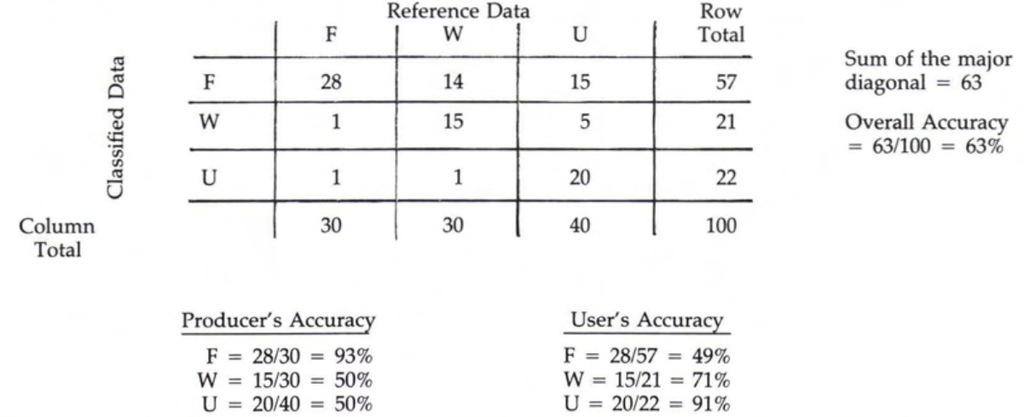

## Classification results

### Accuracy by algorithm

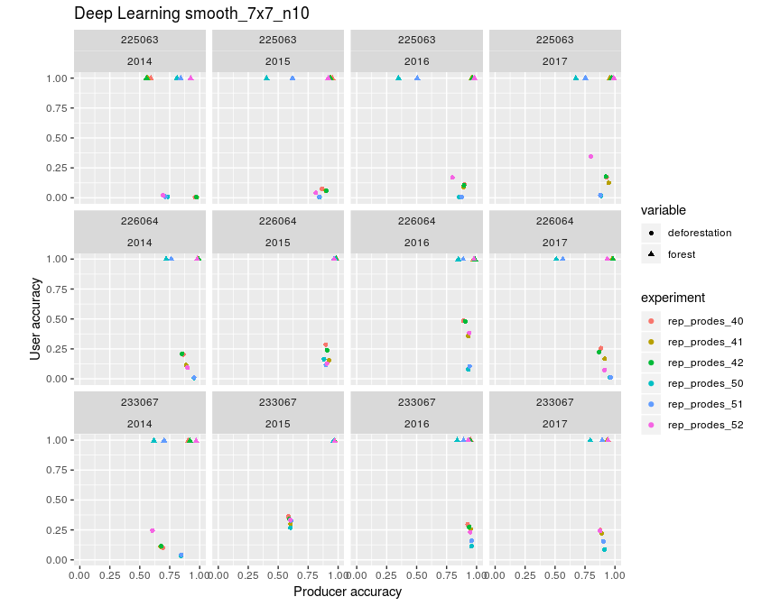

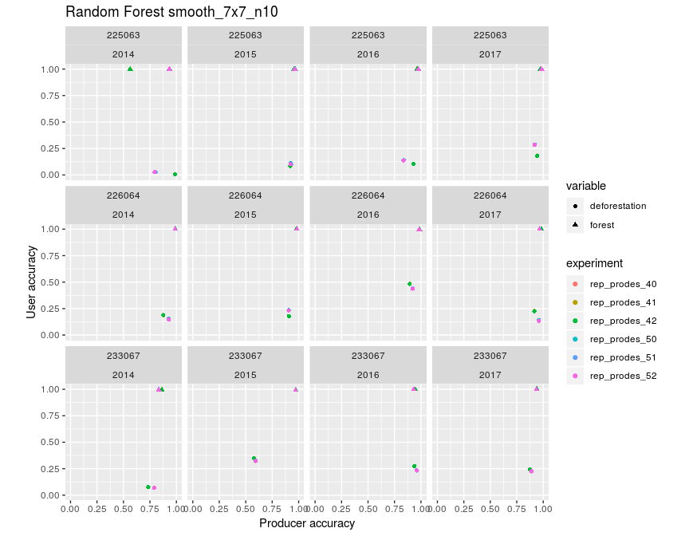

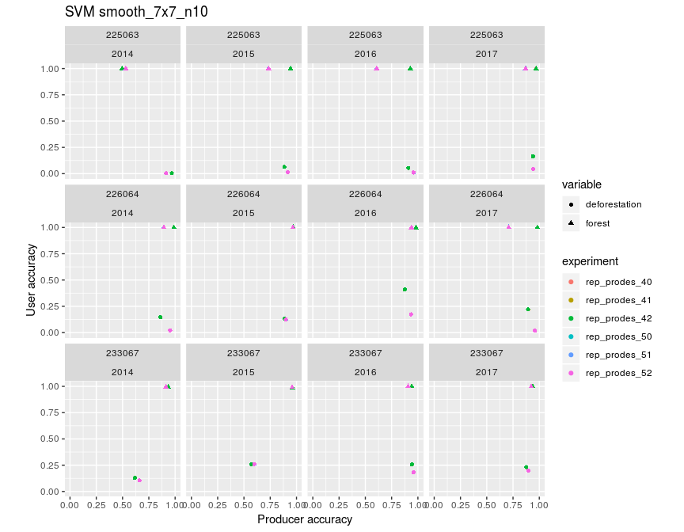

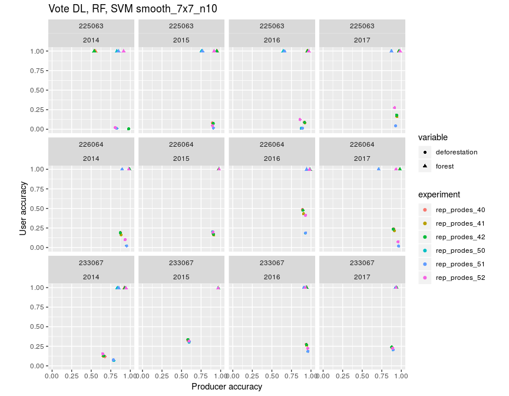

### Accuracy by algorithm and smooth

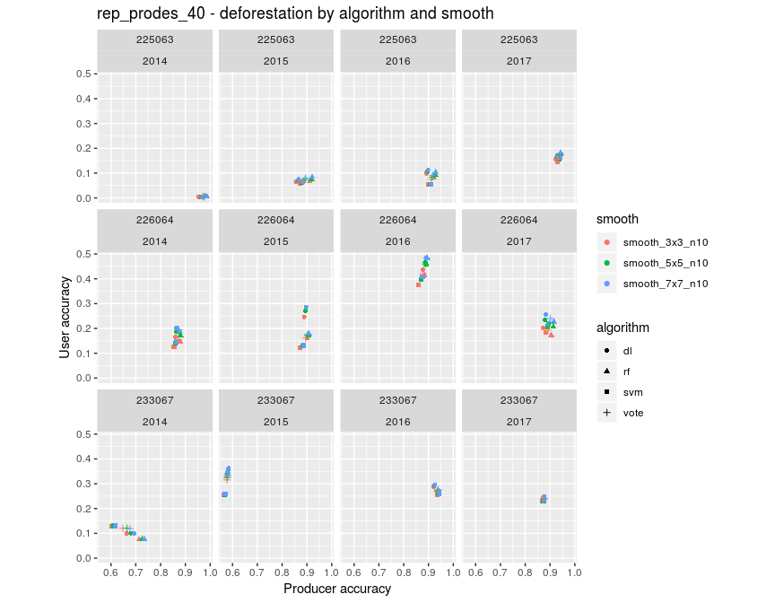

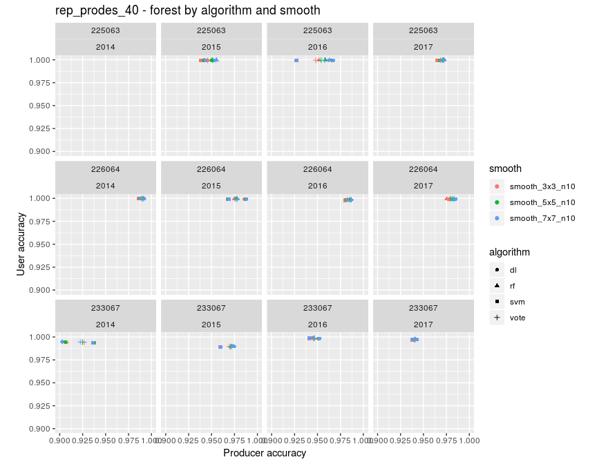

### Confusion matrix rep_prodes_40 225063 2014 dl smooth_3x3_n10

|  | forest | deforestation | user_acc |
| --- | --- | --- | --- |
| forest | 16180474.00 | 2987.00 | 1.00 |
| deforestation | 11198226.00 | 60727.00 | 0.01 |
| prod_acc | 0.59 | 0.95 | NA |

### Confusion matrix rep_prodes_40 225063 2014 dl smooth_5x5_n10

|  | forest | deforestation | user_acc |
| --- | --- | --- | --- |
| forest | 16220823.00 | 2627.00 | 1.00 |
| deforestation | 11157877.00 | 61087.00 | 0.01 |
| prod_acc | 0.59 | 0.96 | NA |

### Confusion matrix rep_prodes_40 225063 2014 dl smooth_7x7_n10

|  | forest | deforestation | user_acc |
| --- | --- | --- | --- |
| forest | 16217536.00 | 2479.00 | 1.00 |
| deforestation | 11161164.00 | 61235.00 | 0.01 |
| prod_acc | 0.59 | 0.96 | NA |

### Confusion matrix rep_prodes_40 225063 2015 dl smooth_3x3_n10

|  | forest | deforestation | user_acc |
| --- | --- | --- | --- |
| forest | 25892203.00 | 17496.00 | 1.00 |
| deforestation | 1486497.00 | 103766.00 | 0.07 |
| prod_acc | 0.95 | 0.86 | NA |

### Confusion matrix rep_prodes_40 225063 2015 dl smooth_5x5_n10

|  | forest | deforestation | user_acc |
| --- | --- | --- | --- |
| forest | 26010982.00 | 16507.00 | 1.00 |
| deforestation | 1367718.00 | 104755.00 | 0.07 |
| prod_acc | 0.95 | 0.86 | NA |

### Confusion matrix rep_prodes_40 225063 2015 dl smooth_7x7_n10

|  | forest | deforestation | user_acc |
| --- | --- | --- | --- |
| forest | 26082384.00 | 16212.00 | 1.00 |
| deforestation | 1296316.00 | 105050.00 | 0.07 |
| prod_acc | 0.95 | 0.87 | NA |

### Confusion matrix rep_prodes_40 225063 2016 dl smooth_3x3_n10

|  | forest | deforestation | user_acc |
| --- | --- | --- | --- |
| forest | 26348762.00 | 13708.00 | 1.0 |
| deforestation | 1029938.00 | 112540.00 | 0.1 |
| prod_acc | 0.96 | 0.89 | NA |

### Confusion matrix rep_prodes_40 225063 2016 dl smooth_5x5_n10

|  | forest | deforestation | user_acc |
| --- | --- | --- | --- |
| forest | 26436929.00 | 13111.0 | 1.00 |
| deforestation | 941771.00 | 113137.0 | 0.11 |
| prod_acc | 0.97 | 0.9 | NA |

### Confusion matrix rep_prodes_40 225063 2016 dl smooth_7x7_n10

|  | forest | deforestation | user_acc |
| --- | --- | --- | --- |
| forest | 26481857.00 | 12914.0 | 1.00 |
| deforestation | 896843.00 | 113334.0 | 0.11 |
| prod_acc | 0.97 | 0.9 | NA |

### Confusion matrix rep_prodes_40 225063 2017 dl smooth_3x3_n10

|  | forest | deforestation | user_acc |
| --- | --- | --- | --- |
| forest | 26507657.00 | 13453.00 | 1.00 |
| deforestation | 871043.00 | 162316.00 | 0.16 |
| prod_acc | 0.97 | 0.92 | NA |

### Confusion matrix rep_prodes_40 225063 2017 dl smooth_5x5_n10

|  | forest | deforestation | user_acc |
| --- | --- | --- | --- |
| forest | 26563958.00 | 12582.00 | 1.00 |
| deforestation | 814742.00 | 163187.00 | 0.17 |
| prod_acc | 0.97 | 0.93 | NA |

### Confusion matrix rep_prodes_40 225063 2017 dl smooth_7x7_n10

|  | forest | deforestation | user_acc |
| --- | --- | --- | --- |
| forest | 26592821.00 | 12287.00 | 1.00 |
| deforestation | 785879.00 | 163482.00 | 0.17 |
| prod_acc | 0.97 | 0.93 | NA |

### Confusion matrix rep_prodes_40 226064 2014 dl smooth_3x3_n10

|  | forest | deforestation | user_acc |
| --- | --- | --- | --- |
| forest | 25807420.00 | 8610.00 | 1.00 |
| deforestation | 264597.00 | 52751.00 | 0.17 |
| prod_acc | 0.99 | 0.86 | NA |

### Confusion matrix rep_prodes_40 226064 2014 dl smooth_5x5_n10

|  | forest | deforestation | user_acc |
| --- | --- | --- | --- |
| forest | 25844085.00 | 8375.00 | 1.00 |
| deforestation | 227932.00 | 52986.00 | 0.19 |
| prod_acc | 0.99 | 0.86 | NA |

### Confusion matrix rep_prodes_40 226064 2014 dl smooth_7x7_n10

|  | forest | deforestation | user_acc |
| --- | --- | --- | --- |
| forest | 25863855.00 | 8368.00 | 1.0 |
| deforestation | 208162.00 | 52993.00 | 0.2 |
| prod_acc | 0.99 | 0.86 | NA |

### Confusion matrix rep_prodes_40 226064 2015 dl smooth_3x3_n10

|  | forest | deforestation | user_acc |
| --- | --- | --- | --- |
| forest | 25699359.00 | 15252.00 | 1.00 |
| deforestation | 372658.00 | 122076.00 | 0.25 |
| prod_acc | 0.99 | 0.89 | NA |

### Confusion matrix rep_prodes_40 226064 2015 dl smooth_5x5_n10

|  | forest | deforestation | user_acc |
| --- | --- | --- | --- |
| forest | 25741666.00 | 14442.00 | 1.00 |
| deforestation | 330351.00 | 122886.00 | 0.27 |
| prod_acc | 0.99 | 0.89 | NA |

### Confusion matrix rep_prodes_40 226064 2015 dl smooth_7x7_n10

|  | forest | deforestation | user_acc |
| --- | --- | --- | --- |
| forest | 25765460.00 | 14191.0 | 1.00 |
| deforestation | 306557.00 | 123137.0 | 0.29 |
| prod_acc | 0.99 | 0.9 | NA |

### Confusion matrix rep_prodes_40 226064 2016 dl smooth_3x3_n10

|  | forest | deforestation | user_acc |
| --- | --- | --- | --- |
| forest | 25664973.00 | 43821.00 | 1.00 |
| deforestation | 407044.00 | 315415.00 | 0.44 |
| prod_acc | 0.98 | 0.88 | NA |

### Confusion matrix rep_prodes_40 226064 2016 dl smooth_5x5_n10

|  | forest | deforestation | user_acc |
| --- | --- | --- | --- |
| forest | 25709309.00 | 40694.00 | 1.00 |
| deforestation | 362708.00 | 318542.00 | 0.47 |
| prod_acc | 0.99 | 0.89 | NA |

### Confusion matrix rep_prodes_40 226064 2016 dl smooth_7x7_n10

|  | forest | deforestation | user_acc |
| --- | --- | --- | --- |
| forest | 25731991.00 | 39474.00 | 1.00 |
| deforestation | 340026.00 | 319762.00 | 0.48 |
| prod_acc | 0.99 | 0.89 | NA |

### Confusion matrix rep_prodes_40 226064 2017 dl smooth_3x3_n10

|  | forest | deforestation | user_acc |
| --- | --- | --- | --- |
| forest | 25561736.00 | 18989.00 | 1.0 |
| deforestation | 510281.00 | 129765.00 | 0.2 |
| prod_acc | 0.98 | 0.87 | NA |

### Confusion matrix rep_prodes_40 226064 2017 dl smooth_5x5_n10

|  | forest | deforestation | user_acc |
| --- | --- | --- | --- |
| forest | 25645816.00 | 17999.00 | 1.00 |
| deforestation | 426201.00 | 130755.00 | 0.23 |
| prod_acc | 0.98 | 0.88 | NA |

### Confusion matrix rep_prodes_40 226064 2017 dl smooth_7x7_n10

|  | forest | deforestation | user_acc |
| --- | --- | --- | --- |
| forest | 25691101.00 | 17537.00 | 1.00 |
| deforestation | 380916.00 | 131217.00 | 0.26 |
| prod_acc | 0.99 | 0.88 | NA |

### Confusion matrix rep_prodes_40 233067 2014 dl smooth_3x3_n10

|  | forest | deforestation | user_acc |
| --- | --- | --- | --- |
| forest | 10855830.00 | 62487.00 | 0.99 |
| deforestation | 1109362.00 | 122941.00 | 0.10 |
| prod_acc | 0.91 | 0.66 | NA |

### Confusion matrix rep_prodes_40 233067 2014 dl smooth_5x5_n10

|  | forest | deforestation | user_acc |
| --- | --- | --- | --- |
| forest | 10839932.00 | 59184.00 | 0.99 |
| deforestation | 1125260.00 | 126244.00 | 0.10 |
| prod_acc | 0.91 | 0.68 | NA |

### Confusion matrix rep_prodes_40 233067 2014 dl smooth_7x7_n10

|  | forest | deforestation | user_acc |
| --- | --- | --- | --- |
| forest | 10800673.0 | 56755.00 | 0.99 |
| deforestation | 1164519.0 | 128673.00 | 0.10 |
| prod_acc | 0.9 | 0.69 | NA |

### Confusion matrix rep_prodes_40 233067 2015 dl smooth_3x3_n10

|  | forest | deforestation | user_acc |
| --- | --- | --- | --- |
| forest | 11644659.00 | 122477.00 | 0.99 |
| deforestation | 320533.00 | 169698.00 | 0.35 |
| prod_acc | 0.97 | 0.58 | NA |

### Confusion matrix rep_prodes_40 233067 2015 dl smooth_5x5_n10

|  | forest | deforestation | user_acc |
| --- | --- | --- | --- |
| forest | 11657195.00 | 121882.00 | 0.99 |
| deforestation | 307997.00 | 170293.00 | 0.36 |
| prod_acc | 0.97 | 0.58 | NA |

### Confusion matrix rep_prodes_40 233067 2015 dl smooth_7x7_n10

|  | forest | deforestation | user_acc |
| --- | --- | --- | --- |
| forest | 11664674.00 | 121636.00 | 0.99 |
| deforestation | 300518.00 | 170539.00 | 0.36 |
| prod_acc | 0.97 | 0.58 | NA |

### Confusion matrix rep_prodes_40 233067 2016 dl smooth_3x3_n10

|  | forest | deforestation | user_acc |
| --- | --- | --- | --- |
| forest | 11377713.00 | 20617.00 | 1.00 |
| deforestation | 587479.00 | 238353.00 | 0.29 |
| prod_acc | 0.95 | 0.92 | NA |

### Confusion matrix rep_prodes_40 233067 2016 dl smooth_5x5_n10

|  | forest | deforestation | user_acc |
| --- | --- | --- | --- |
| forest | 11388707.00 | 19600.00 | 1.00 |
| deforestation | 576485.00 | 239370.00 | 0.29 |
| prod_acc | 0.95 | 0.92 | NA |

### Confusion matrix rep_prodes_40 233067 2016 dl smooth_7x7_n10

|  | forest | deforestation | user_acc |
| --- | --- | --- | --- |
| forest | 11394880.00 | 19186.00 | 1.0 |
| deforestation | 570312.00 | 239784.00 | 0.3 |
| prod_acc | 0.95 | 0.93 | NA |

### Confusion matrix rep_prodes_40 233067 2017 dl smooth_3x3_n10

|  | forest | deforestation | user_acc |
| --- | --- | --- | --- |
| forest | 11272543.00 | 32521.00 | 1.00 |
| deforestation | 692649.00 | 223003.00 | 0.24 |
| prod_acc | 0.94 | 0.87 | NA |

### Confusion matrix rep_prodes_40 233067 2017 dl smooth_5x5_n10

|  | forest | deforestation | user_acc |
| --- | --- | --- | --- |
| forest | 11281449.00 | 31784.00 | 1.00 |
| deforestation | 683743.00 | 223740.00 | 0.25 |
| prod_acc | 0.94 | 0.88 | NA |

### Confusion matrix rep_prodes_40 233067 2017 dl smooth_7x7_n10

|  | forest | deforestation | user_acc |
| --- | --- | --- | --- |
| forest | 11286046.00 | 31444.00 | 1.00 |
| deforestation | 679146.00 | 224080.00 | 0.25 |
| prod_acc | 0.94 | 0.88 | NA |

### Confusion matrix rep_prodes_40 225063 2014 rf smooth_3x3_n10

|  | forest | deforestation | user_acc |
| --- | --- | --- | --- |
| forest | 15103430.00 | 1354.00 | 1.00 |
| deforestation | 12275270.00 | 62360.00 | 0.01 |
| prod_acc | 0.55 | 0.98 | NA |

### Confusion matrix rep_prodes_40 225063 2014 rf smooth_5x5_n10

|  | forest | deforestation | user_acc |
| --- | --- | --- | --- |
| forest | 15284758.00 | 982.00 | 1.00 |
| deforestation | 12093942.00 | 62732.00 | 0.01 |
| prod_acc | 0.56 | 0.98 | NA |

### Confusion matrix rep_prodes_40 225063 2014 rf smooth_7x7_n10

|  | forest | deforestation | user_acc |
| --- | --- | --- | --- |
| forest | 15403381.00 | 801.00 | 1.00 |
| deforestation | 11975319.00 | 62913.00 | 0.01 |
| prod_acc | 0.56 | 0.99 | NA |

### Confusion matrix rep_prodes_40 225063 2015 rf smooth_3x3_n10

|  | forest | deforestation | user_acc |
| --- | --- | --- | --- |
| forest | 25806106.00 | 10788.00 | 1.00 |
| deforestation | 1572594.00 | 110474.00 | 0.07 |
| prod_acc | 0.94 | 0.91 | NA |

### Confusion matrix rep_prodes_40 225063 2015 rf smooth_5x5_n10

|  | forest | deforestation | user_acc |
| --- | --- | --- | --- |
| forest | 26017676.00 | 9935.00 | 1.00 |
| deforestation | 1361024.00 | 111327.00 | 0.08 |
| prod_acc | 0.95 | 0.92 | NA |

### Confusion matrix rep_prodes_40 225063 2015 rf smooth_7x7_n10

|  | forest | deforestation | user_acc |
| --- | --- | --- | --- |
| forest | 26158796.00 | 9605.00 | 1.00 |
| deforestation | 1219904.00 | 111657.00 | 0.08 |
| prod_acc | 0.96 | 0.92 | NA |

### Confusion matrix rep_prodes_40 225063 2016 rf smooth_3x3_n10

|  | forest | deforestation | user_acc |
| --- | --- | --- | --- |
| forest | 26050007.00 | 9742.00 | 1.00 |
| deforestation | 1328693.00 | 116506.00 | 0.08 |
| prod_acc | 0.95 | 0.92 | NA |

### Confusion matrix rep_prodes_40 225063 2016 rf smooth_5x5_n10

|  | forest | deforestation | user_acc |
| --- | --- | --- | --- |
| forest | 26240475.00 | 9153.00 | 1.00 |
| deforestation | 1138225.00 | 117095.00 | 0.09 |
| prod_acc | 0.96 | 0.93 | NA |

### Confusion matrix rep_prodes_40 225063 2016 rf smooth_7x7_n10

|  | forest | deforestation | user_acc |
| --- | --- | --- | --- |
| forest | 26361323.00 | 8952.00 | 1.0 |
| deforestation | 1017377.00 | 117296.00 | 0.1 |
| prod_acc | 0.96 | 0.93 | NA |

### Confusion matrix rep_prodes_40 225063 2017 rf smooth_3x3_n10

|  | forest | deforestation | user_acc |
| --- | --- | --- | --- |
| forest | 26523717.00 | 10820.00 | 1.00 |
| deforestation | 854983.00 | 164949.00 | 0.16 |
| prod_acc | 0.97 | 0.94 | NA |

### Confusion matrix rep_prodes_40 225063 2017 rf smooth_5x5_n10

|  | forest | deforestation | user_acc |
| --- | --- | --- | --- |
| forest | 26601712.00 | 10084.00 | 1.00 |
| deforestation | 776988.00 | 165685.00 | 0.18 |
| prod_acc | 0.97 | 0.94 | NA |

### Confusion matrix rep_prodes_40 225063 2017 rf smooth_7x7_n10

|  | forest | deforestation | user_acc |
| --- | --- | --- | --- |
| forest | 26634283.00 | 9973.00 | 1.00 |
| deforestation | 744417.00 | 165796.00 | 0.18 |
| prod_acc | 0.97 | 0.94 | NA |

### Confusion matrix rep_prodes_40 226064 2014 rf smooth_3x3_n10

|  | forest | deforestation | user_acc |
| --- | --- | --- | --- |
| forest | 25758497.00 | 7413.00 | 1.00 |
| deforestation | 313520.00 | 53948.00 | 0.15 |
| prod_acc | 0.99 | 0.88 | NA |

### Confusion matrix rep_prodes_40 226064 2014 rf smooth_5x5_n10

|  | forest | deforestation | user_acc |
| --- | --- | --- | --- |
| forest | 25813314.00 | 7371.00 | 1.00 |
| deforestation | 258703.00 | 53990.00 | 0.17 |
| prod_acc | 0.99 | 0.88 | NA |

### Confusion matrix rep_prodes_40 226064 2014 rf smooth_7x7_n10

|  | forest | deforestation | user_acc |
| --- | --- | --- | --- |
| forest | 25840893.00 | 7589.00 | 1.00 |
| deforestation | 231124.00 | 53772.00 | 0.19 |
| prod_acc | 0.99 | 0.88 | NA |

### Confusion matrix rep_prodes_40 226064 2015 rf smooth_3x3_n10

|  | forest | deforestation | user_acc |
| --- | --- | --- | --- |
| forest | 25416043.00 | 13583.0 | 1.00 |
| deforestation | 655974.00 | 123745.0 | 0.16 |
| prod_acc | 0.97 | 0.9 | NA |

### Confusion matrix rep_prodes_40 226064 2015 rf smooth_5x5_n10

|  | forest | deforestation | user_acc |
| --- | --- | --- | --- |
| forest | 25471118.00 | 12840.00 | 1.00 |
| deforestation | 600899.00 | 124488.00 | 0.17 |
| prod_acc | 0.98 | 0.91 | NA |

### Confusion matrix rep_prodes_40 226064 2015 rf smooth_7x7_n10

|  | forest | deforestation | user_acc |
| --- | --- | --- | --- |
| forest | 25501993.00 | 12718.00 | 1.00 |
| deforestation | 570024.00 | 124610.00 | 0.18 |
| prod_acc | 0.98 | 0.91 | NA |

### Confusion matrix rep_prodes_40 226064 2016 rf smooth_3x3_n10

|  | forest | deforestation | user_acc |
| --- | --- | --- | --- |
| forest | 25621029.00 | 41637.00 | 1.00 |
| deforestation | 450988.00 | 317599.00 | 0.41 |
| prod_acc | 0.98 | 0.88 | NA |

### Confusion matrix rep_prodes_40 226064 2016 rf smooth_5x5_n10

|  | forest | deforestation | user_acc |
| --- | --- | --- | --- |
| forest | 25692515.00 | 39146.00 | 1.00 |
| deforestation | 379502.00 | 320090.00 | 0.46 |
| prod_acc | 0.99 | 0.89 | NA |

### Confusion matrix rep_prodes_40 226064 2016 rf smooth_7x7_n10

|  | forest | deforestation | user_acc |
| --- | --- | --- | --- |
| forest | 25729587.00 | 37969.00 | 1.00 |
| deforestation | 342430.00 | 321267.00 | 0.48 |
| prod_acc | 0.99 | 0.89 | NA |

### Confusion matrix rep_prodes_40 226064 2017 rf smooth_3x3_n10

|  | forest | deforestation | user_acc |
| --- | --- | --- | --- |
| forest | 25427723.00 | 14093.00 | 1.00 |
| deforestation | 644294.00 | 134661.00 | 0.17 |
| prod_acc | 0.98 | 0.91 | NA |

### Confusion matrix rep_prodes_40 226064 2017 rf smooth_5x5_n10

|  | forest | deforestation | user_acc |
| --- | --- | --- | --- |
| forest | 25549334.00 | 12852.00 | 1.00 |
| deforestation | 522683.00 | 135902.00 | 0.21 |
| prod_acc | 0.98 | 0.91 | NA |

### Confusion matrix rep_prodes_40 226064 2017 rf smooth_7x7_n10

|  | forest | deforestation | user_acc |
| --- | --- | --- | --- |
| forest | 25608246.00 | 12542.00 | 1.00 |
| deforestation | 463771.00 | 136212.00 | 0.23 |
| prod_acc | 0.98 | 0.92 | NA |

### Confusion matrix rep_prodes_40 233067 2014 rf smooth_3x3_n10

|  | forest | deforestation | user_acc |
| --- | --- | --- | --- |
| forest | 10326714.00 | 53134.00 | 0.99 |
| deforestation | 1638478.00 | 132294.00 | 0.07 |
| prod_acc | 0.86 | 0.71 | NA |

### Confusion matrix rep_prodes_40 233067 2014 rf smooth_5x5_n10

|  | forest | deforestation | user_acc |
| --- | --- | --- | --- |
| forest | 10331504.00 | 50822.00 | 1.00 |
| deforestation | 1633688.00 | 134606.00 | 0.08 |
| prod_acc | 0.86 | 0.73 | NA |

### Confusion matrix rep_prodes_40 233067 2014 rf smooth_7x7_n10

|  | forest | deforestation | user_acc |
| --- | --- | --- | --- |
| forest | 10331574.00 | 49282.00 | 1.00 |
| deforestation | 1633618.00 | 136146.00 | 0.08 |
| prod_acc | 0.86 | 0.73 | NA |

### Confusion matrix rep_prodes_40 233067 2015 rf smooth_3x3_n10

|  | forest | deforestation | user_acc |
| --- | --- | --- | --- |
| forest | 11619873.00 | 123531.00 | 0.99 |
| deforestation | 345319.00 | 168644.00 | 0.33 |
| prod_acc | 0.97 | 0.58 | NA |

### Confusion matrix rep_prodes_40 233067 2015 rf smooth_5x5_n10

|  | forest | deforestation | user_acc |
| --- | --- | --- | --- |
| forest | 11636956.00 | 123063.00 | 0.99 |
| deforestation | 328236.00 | 169112.00 | 0.34 |
| prod_acc | 0.97 | 0.58 | NA |

### Confusion matrix rep_prodes_40 233067 2015 rf smooth_7x7_n10

|  | forest | deforestation | user_acc |
| --- | --- | --- | --- |
| forest | 11649061.00 | 123103.00 | 0.99 |
| deforestation | 316131.00 | 169072.00 | 0.35 |
| prod_acc | 0.97 | 0.58 | NA |

### Confusion matrix rep_prodes_40 233067 2016 rf smooth_3x3_n10

|  | forest | deforestation | user_acc |
| --- | --- | --- | --- |
| forest | 11300988.00 | 16481.00 | 1.00 |
| deforestation | 664204.00 | 242489.00 | 0.27 |
| prod_acc | 0.94 | 0.94 | NA |

### Confusion matrix rep_prodes_40 233067 2016 rf smooth_5x5_n10

|  | forest | deforestation | user_acc |
| --- | --- | --- | --- |
| forest | 11313872.00 | 15900.00 | 1.00 |
| deforestation | 651320.00 | 243070.00 | 0.27 |
| prod_acc | 0.95 | 0.94 | NA |

### Confusion matrix rep_prodes_40 233067 2016 rf smooth_7x7_n10

|  | forest | deforestation | user_acc |
| --- | --- | --- | --- |
| forest | 11321344.00 | 15755.00 | 1.00 |
| deforestation | 643848.00 | 243215.00 | 0.27 |
| prod_acc | 0.95 | 0.94 | NA |

### Confusion matrix rep_prodes_40 233067 2017 rf smooth_3x3_n10

|  | forest | deforestation | user_acc |
| --- | --- | --- | --- |
| forest | 11252118.00 | 32992.00 | 1.00 |
| deforestation | 713074.00 | 222532.00 | 0.24 |
| prod_acc | 0.94 | 0.87 | NA |

### Confusion matrix rep_prodes_40 233067 2017 rf smooth_5x5_n10

|  | forest | deforestation | user_acc |
| --- | --- | --- | --- |
| forest | 11262798.00 | 32423.00 | 1.00 |
| deforestation | 702394.00 | 223101.00 | 0.24 |
| prod_acc | 0.94 | 0.87 | NA |

### Confusion matrix rep_prodes_40 233067 2017 rf smooth_7x7_n10

|  | forest | deforestation | user_acc |
| --- | --- | --- | --- |
| forest | 11267607.00 | 32198.00 | 1.00 |
| deforestation | 697585.00 | 223326.00 | 0.24 |
| prod_acc | 0.94 | 0.87 | NA |

### Confusion matrix rep_prodes_40 225063 2014 svm smooth_3x3_n10

|  | forest | deforestation | user_acc |
| --- | --- | --- | --- |
| forest | 13784287.0 | 2601.00 | 1 |
| deforestation | 13594413.0 | 61113.00 | 0 |
| prod_acc | 0.5 | 0.96 | NA |

### Confusion matrix rep_prodes_40 225063 2014 svm smooth_5x5_n10

|  | forest | deforestation | user_acc |
| --- | --- | --- | --- |
| forest | 13678434.0 | 2203.00 | 1 |
| deforestation | 13700266.0 | 61511.00 | 0 |
| prod_acc | 0.5 | 0.97 | NA |

### Confusion matrix rep_prodes_40 225063 2014 svm smooth_7x7_n10

|  | forest | deforestation | user_acc |
| --- | --- | --- | --- |
| forest | 13561344.0 | 2007.00 | 1 |
| deforestation | 13817356.0 | 61707.00 | 0 |
| prod_acc | 0.5 | 0.97 | NA |

### Confusion matrix rep_prodes_40 225063 2015 svm smooth_3x3_n10

|  | forest | deforestation | user_acc |
| --- | --- | --- | --- |
| forest | 25690437.00 | 15606.00 | 1.00 |
| deforestation | 1688263.00 | 105656.00 | 0.06 |
| prod_acc | 0.94 | 0.87 | NA |

### Confusion matrix rep_prodes_40 225063 2015 svm smooth_5x5_n10

|  | forest | deforestation | user_acc |
| --- | --- | --- | --- |
| forest | 25782726.00 | 14539.00 | 1.00 |
| deforestation | 1595974.00 | 106723.00 | 0.06 |
| prod_acc | 0.94 | 0.88 | NA |

### Confusion matrix rep_prodes_40 225063 2015 svm smooth_7x7_n10

|  | forest | deforestation | user_acc |
| --- | --- | --- | --- |
| forest | 25832353.00 | 14019.00 | 1.00 |
| deforestation | 1546347.00 | 107243.00 | 0.06 |
| prod_acc | 0.94 | 0.88 | NA |

### Confusion matrix rep_prodes_40 225063 2016 svm smooth_3x3_n10

|  | forest | deforestation | user_acc |
| --- | --- | --- | --- |
| forest | 25362608.00 | 12544.0 | 1.00 |
| deforestation | 2016092.00 | 113704.0 | 0.05 |
| prod_acc | 0.93 | 0.9 | NA |

### Confusion matrix rep_prodes_40 225063 2016 svm smooth_5x5_n10

|  | forest | deforestation | user_acc |
| --- | --- | --- | --- |
| forest | 25391045.00 | 11718.00 | 1.00 |
| deforestation | 1987655.00 | 114530.00 | 0.05 |
| prod_acc | 0.93 | 0.91 | NA |

### Confusion matrix rep_prodes_40 225063 2016 svm smooth_7x7_n10

|  | forest | deforestation | user_acc |
| --- | --- | --- | --- |
| forest | 25398004.00 | 11361.00 | 1.00 |
| deforestation | 1980696.00 | 114887.00 | 0.05 |
| prod_acc | 0.93 | 0.91 | NA |

### Confusion matrix rep_prodes_40 225063 2017 svm smooth_3x3_n10

|  | forest | deforestation | user_acc |
| --- | --- | --- | --- |
| forest | 26423882.00 | 12158.00 | 1.00 |
| deforestation | 954818.00 | 163611.00 | 0.15 |
| prod_acc | 0.97 | 0.93 | NA |

### Confusion matrix rep_prodes_40 225063 2017 svm smooth_5x5_n10

|  | forest | deforestation | user_acc |
| --- | --- | --- | --- |
| forest | 26501814.00 | 11075.00 | 1.00 |
| deforestation | 876886.00 | 164694.00 | 0.16 |
| prod_acc | 0.97 | 0.94 | NA |

### Confusion matrix rep_prodes_40 225063 2017 svm smooth_7x7_n10

|  | forest | deforestation | user_acc |
| --- | --- | --- | --- |
| forest | 26539817.00 | 10672.00 | 1.00 |
| deforestation | 838883.00 | 165097.00 | 0.16 |
| prod_acc | 0.97 | 0.94 | NA |

### Confusion matrix rep_prodes_40 226064 2014 svm smooth_3x3_n10

|  | forest | deforestation | user_acc |
| --- | --- | --- | --- |
| forest | 25712490.00 | 8969.00 | 1.00 |
| deforestation | 359527.00 | 52392.00 | 0.13 |
| prod_acc | 0.99 | 0.85 | NA |

### Confusion matrix rep_prodes_40 226064 2014 svm smooth_5x5_n10

|  | forest | deforestation | user_acc |
| --- | --- | --- | --- |
| forest | 25745768.00 | 8578.00 | 1.00 |
| deforestation | 326249.00 | 52783.00 | 0.14 |
| prod_acc | 0.99 | 0.86 | NA |

### Confusion matrix rep_prodes_40 226064 2014 svm smooth_7x7_n10

|  | forest | deforestation | user_acc |
| --- | --- | --- | --- |
| forest | 25761790.00 | 8471.00 | 1.00 |
| deforestation | 310227.00 | 52890.00 | 0.15 |
| prod_acc | 0.99 | 0.86 | NA |

### Confusion matrix rep_prodes_40 226064 2015 svm smooth_3x3_n10

|  | forest | deforestation | user_acc |
| --- | --- | --- | --- |
| forest | 25222854.00 | 17388.00 | 1.00 |
| deforestation | 849163.00 | 119940.00 | 0.12 |
| prod_acc | 0.97 | 0.87 | NA |

### Confusion matrix rep_prodes_40 226064 2015 svm smooth_5x5_n10

|  | forest | deforestation | user_acc |
| --- | --- | --- | --- |
| forest | 25252187.00 | 15947.00 | 1.00 |
| deforestation | 819830.00 | 121381.00 | 0.13 |
| prod_acc | 0.97 | 0.88 | NA |

### Confusion matrix rep_prodes_40 226064 2015 svm smooth_7x7_n10

|  | forest | deforestation | user_acc |
| --- | --- | --- | --- |
| forest | 25265519.00 | 15431.00 | 1.00 |
| deforestation | 806498.00 | 121897.00 | 0.13 |
| prod_acc | 0.97 | 0.89 | NA |

### Confusion matrix rep_prodes_40 226064 2016 svm smooth_3x3_n10

|  | forest | deforestation | user_acc |
| --- | --- | --- | --- |
| forest | 25560816.00 | 50930.00 | 1.00 |
| deforestation | 511201.00 | 308306.00 | 0.38 |
| prod_acc | 0.98 | 0.86 | NA |

### Confusion matrix rep_prodes_40 226064 2016 svm smooth_5x5_n10

|  | forest | deforestation | user_acc |
| --- | --- | --- | --- |
| forest | 25599196.00 | 46719.00 | 1.0 |
| deforestation | 472821.00 | 312517.00 | 0.4 |
| prod_acc | 0.98 | 0.87 | NA |

### Confusion matrix rep_prodes_40 226064 2016 svm smooth_7x7_n10

|  | forest | deforestation | user_acc |
| --- | --- | --- | --- |
| forest | 25618186.00 | 44722.00 | 1.00 |
| deforestation | 453831.00 | 314514.00 | 0.41 |
| prod_acc | 0.98 | 0.88 | NA |

### Confusion matrix rep_prodes_40 226064 2017 svm smooth_3x3_n10

|  | forest | deforestation | user_acc |
| --- | --- | --- | --- |
| forest | 25486755.00 | 17583.00 | 1.00 |
| deforestation | 585262.00 | 131171.00 | 0.18 |
| prod_acc | 0.98 | 0.88 | NA |

### Confusion matrix rep_prodes_40 226064 2017 svm smooth_5x5_n10

|  | forest | deforestation | user_acc |
| --- | --- | --- | --- |
| forest | 25564848.00 | 16269.00 | 1.00 |
| deforestation | 507169.00 | 132485.00 | 0.21 |
| prod_acc | 0.98 | 0.89 | NA |

### Confusion matrix rep_prodes_40 226064 2017 svm smooth_7x7_n10

|  | forest | deforestation | user_acc |
| --- | --- | --- | --- |
| forest | 25602983.00 | 15800.00 | 1.00 |
| deforestation | 469034.00 | 132954.00 | 0.22 |
| prod_acc | 0.98 | 0.89 | NA |

### Confusion matrix rep_prodes_40 233067 2014 svm smooth_3x3_n10

|  | forest | deforestation | user_acc |
| --- | --- | --- | --- |
| forest | 11216959.00 | 73698.0 | 0.99 |
| deforestation | 748233.00 | 111730.0 | 0.13 |
| prod_acc | 0.94 | 0.6 | NA |

### Confusion matrix rep_prodes_40 233067 2014 svm smooth_5x5_n10

|  | forest | deforestation | user_acc |
| --- | --- | --- | --- |
| forest | 11211767.00 | 72169.00 | 0.99 |
| deforestation | 753425.00 | 113259.00 | 0.13 |
| prod_acc | 0.94 | 0.61 | NA |

### Confusion matrix rep_prodes_40 233067 2014 svm smooth_7x7_n10

|  | forest | deforestation | user_acc |
| --- | --- | --- | --- |
| forest | 11200294.00 | 71081.00 | 0.99 |
| deforestation | 764898.00 | 114347.00 | 0.13 |
| prod_acc | 0.94 | 0.62 | NA |

### Confusion matrix rep_prodes_40 233067 2015 svm smooth_3x3_n10

|  | forest | deforestation | user_acc |
| --- | --- | --- | --- |
| forest | 11479687.00 | 126846.00 | 0.99 |
| deforestation | 485505.00 | 165329.00 | 0.25 |
| prod_acc | 0.96 | 0.57 | NA |

### Confusion matrix rep_prodes_40 233067 2015 svm smooth_5x5_n10

|  | forest | deforestation | user_acc |
| --- | --- | --- | --- |
| forest | 11485187.00 | 125867.00 | 0.99 |
| deforestation | 480005.00 | 166308.00 | 0.26 |
| prod_acc | 0.96 | 0.57 | NA |

### Confusion matrix rep_prodes_40 233067 2015 svm smooth_7x7_n10

|  | forest | deforestation | user_acc |
| --- | --- | --- | --- |
| forest | 11488009.00 | 125601.00 | 0.99 |
| deforestation | 477183.00 | 166574.00 | 0.26 |
| prod_acc | 0.96 | 0.57 | NA |

### Confusion matrix rep_prodes_40 233067 2016 svm smooth_3x3_n10

|  | forest | deforestation | user_acc |
| --- | --- | --- | --- |
| forest | 11261435.00 | 16839.00 | 1.00 |
| deforestation | 703757.00 | 242131.00 | 0.26 |
| prod_acc | 0.94 | 0.93 | NA |

### Confusion matrix rep_prodes_40 233067 2016 svm smooth_5x5_n10

|  | forest | deforestation | user_acc |
| --- | --- | --- | --- |
| forest | 11263655.00 | 15412.00 | 1.00 |
| deforestation | 701537.00 | 243558.00 | 0.26 |
| prod_acc | 0.94 | 0.94 | NA |

### Confusion matrix rep_prodes_40 233067 2016 svm smooth_7x7_n10

|  | forest | deforestation | user_acc |
| --- | --- | --- | --- |
| forest | 11262355.00 | 14857.00 | 1.00 |
| deforestation | 702837.00 | 244113.00 | 0.26 |
| prod_acc | 0.94 | 0.94 | NA |

### Confusion matrix rep_prodes_40 233067 2017 svm smooth_3x3_n10

|  | forest | deforestation | user_acc |
| --- | --- | --- | --- |
| forest | 11224174.00 | 33318.00 | 1.00 |
| deforestation | 741018.00 | 222206.00 | 0.23 |
| prod_acc | 0.94 | 0.87 | NA |

### Confusion matrix rep_prodes_40 233067 2017 svm smooth_5x5_n10

|  | forest | deforestation | user_acc |
| --- | --- | --- | --- |
| forest | 11225843.00 | 32152.00 | 1.00 |
| deforestation | 739349.00 | 223372.00 | 0.23 |
| prod_acc | 0.94 | 0.87 | NA |

### Confusion matrix rep_prodes_40 233067 2017 svm smooth_7x7_n10

|  | forest | deforestation | user_acc |
| --- | --- | --- | --- |
| forest | 11224235.00 | 31592.00 | 1.00 |
| deforestation | 740957.00 | 223932.00 | 0.23 |
| prod_acc | 0.94 | 0.88 | NA |

### Confusion matrix rep_prodes_40 225063 2014 vote smooth_3x3_n10

|  | forest | deforestation | user_acc |
| --- | --- | --- | --- |
| forest | 14910466.00 | 1986.00 | 1 |
| deforestation | 12468234.00 | 61728.00 | 0 |
| prod_acc | 0.54 | 0.97 | NA |

### Confusion matrix rep_prodes_40 225063 2014 vote smooth_5x5_n10

|  | forest | deforestation | user_acc |
| --- | --- | --- | --- |
| forest | 15093409.00 | 1628.00 | 1.00 |
| deforestation | 12285291.00 | 62086.00 | 0.01 |
| prod_acc | 0.55 | 0.97 | NA |

### Confusion matrix rep_prodes_40 225063 2014 vote smooth_7x7_n10

|  | forest | deforestation | user_acc |
| --- | --- | --- | --- |
| forest | 15212586.00 | 1463.00 | 1.00 |
| deforestation | 12166114.00 | 62251.00 | 0.01 |
| prod_acc | 0.56 | 0.98 | NA |

### Confusion matrix rep_prodes_40 225063 2015 vote smooth_3x3_n10

|  | forest | deforestation | user_acc |
| --- | --- | --- | --- |
| forest | 25893035.00 | 13949.00 | 1.00 |
| deforestation | 1485665.00 | 107313.00 | 0.07 |
| prod_acc | 0.95 | 0.88 | NA |

### Confusion matrix rep_prodes_40 225063 2015 vote smooth_5x5_n10

|  | forest | deforestation | user_acc |
| --- | --- | --- | --- |
| forest | 26044308.00 | 13046.00 | 1.00 |
| deforestation | 1334392.00 | 108216.00 | 0.08 |
| prod_acc | 0.95 | 0.89 | NA |

### Confusion matrix rep_prodes_40 225063 2015 vote smooth_7x7_n10

|  | forest | deforestation | user_acc |
| --- | --- | --- | --- |
| forest | 26137879.00 | 12642.0 | 1.00 |
| deforestation | 1240821.00 | 108620.0 | 0.08 |
| prod_acc | 0.95 | 0.9 | NA |

### Confusion matrix rep_prodes_40 225063 2016 vote smooth_3x3_n10

|  | forest | deforestation | user_acc |
| --- | --- | --- | --- |
| forest | 25954247.00 | 11413.00 | 1.00 |
| deforestation | 1424453.00 | 114835.00 | 0.07 |
| prod_acc | 0.95 | 0.91 | NA |

### Confusion matrix rep_prodes_40 225063 2016 vote smooth_5x5_n10

|  | forest | deforestation | user_acc |
| --- | --- | --- | --- |
| forest | 26118435.00 | 10751.00 | 1.00 |
| deforestation | 1260265.00 | 115497.00 | 0.08 |
| prod_acc | 0.95 | 0.91 | NA |

### Confusion matrix rep_prodes_40 225063 2016 vote smooth_7x7_n10

|  | forest | deforestation | user_acc |
| --- | --- | --- | --- |
| forest | 26222096.00 | 10493.00 | 1.00 |
| deforestation | 1156604.00 | 115755.00 | 0.09 |
| prod_acc | 0.96 | 0.92 | NA |

### Confusion matrix rep_prodes_40 225063 2017 vote smooth_3x3_n10

|  | forest | deforestation | user_acc |
| --- | --- | --- | --- |
| forest | 26523954.00 | 11565.00 | 1.00 |
| deforestation | 854746.00 | 164204.00 | 0.16 |
| prod_acc | 0.97 | 0.93 | NA |

### Confusion matrix rep_prodes_40 225063 2017 vote smooth_5x5_n10

|  | forest | deforestation | user_acc |
| --- | --- | --- | --- |
| forest | 26589841.00 | 10682.00 | 1.00 |
| deforestation | 788859.00 | 165087.00 | 0.17 |
| prod_acc | 0.97 | 0.94 | NA |

### Confusion matrix rep_prodes_40 225063 2017 vote smooth_7x7_n10

|  | forest | deforestation | user_acc |
| --- | --- | --- | --- |
| forest | 26618770.00 | 10405.00 | 1.00 |
| deforestation | 759930.00 | 165364.00 | 0.18 |
| prod_acc | 0.97 | 0.94 | NA |

### Confusion matrix rep_prodes_40 226064 2014 vote smooth_3x3_n10

|  | forest | deforestation | user_acc |
| --- | --- | --- | --- |
| forest | 25780656.00 | 7859.00 | 1.00 |
| deforestation | 291361.00 | 53502.00 | 0.16 |
| prod_acc | 0.99 | 0.87 | NA |

### Confusion matrix rep_prodes_40 226064 2014 vote smooth_5x5_n10

|  | forest | deforestation | user_acc |
| --- | --- | --- | --- |
| forest | 25825734.00 | 7670.00 | 1.00 |
| deforestation | 246283.00 | 53691.00 | 0.18 |
| prod_acc | 0.99 | 0.88 | NA |

### Confusion matrix rep_prodes_40 226064 2014 vote smooth_7x7_n10

|  | forest | deforestation | user_acc |
| --- | --- | --- | --- |
| forest | 25849290.00 | 7712.00 | 1.00 |
| deforestation | 222727.00 | 53649.00 | 0.19 |
| prod_acc | 0.99 | 0.87 | NA |

### Confusion matrix rep_prodes_40 226064 2015 vote smooth_3x3_n10

|  | forest | deforestation | user_acc |
| --- | --- | --- | --- |
| forest | 25430127.00 | 14398.0 | 1.00 |
| deforestation | 641890.00 | 122930.0 | 0.16 |
| prod_acc | 0.98 | 0.9 | NA |

### Confusion matrix rep_prodes_40 226064 2015 vote smooth_5x5_n10

|  | forest | deforestation | user_acc |
| --- | --- | --- | --- |
| forest | 25473235.00 | 13476.0 | 1.00 |
| deforestation | 598782.00 | 123852.0 | 0.17 |
| prod_acc | 0.98 | 0.9 | NA |

### Confusion matrix rep_prodes_40 226064 2015 vote smooth_7x7_n10

|  | forest | deforestation | user_acc |
| --- | --- | --- | --- |
| forest | 25499118.00 | 13232.0 | 1.00 |
| deforestation | 572899.00 | 124096.0 | 0.18 |
| prod_acc | 0.98 | 0.9 | NA |

### Confusion matrix rep_prodes_40 226064 2016 vote smooth_3x3_n10

|  | forest | deforestation | user_acc |
| --- | --- | --- | --- |
| forest | 25637982.00 | 43493.00 | 1.00 |
| deforestation | 434035.00 | 315743.00 | 0.42 |
| prod_acc | 0.98 | 0.88 | NA |

### Confusion matrix rep_prodes_40 226064 2016 vote smooth_5x5_n10

|  | forest | deforestation | user_acc |
| --- | --- | --- | --- |
| forest | 25697163.00 | 40298.00 | 1.00 |
| deforestation | 374854.00 | 318938.00 | 0.46 |
| prod_acc | 0.99 | 0.89 | NA |

### Confusion matrix rep_prodes_40 226064 2016 vote smooth_7x7_n10

|  | forest | deforestation | user_acc |
| --- | --- | --- | --- |
| forest | 25730142.00 | 38856.00 | 1.00 |
| deforestation | 341875.00 | 320380.00 | 0.48 |
| prod_acc | 0.99 | 0.89 | NA |

### Confusion matrix rep_prodes_40 226064 2017 vote smooth_3x3_n10

|  | forest | deforestation | user_acc |
| --- | --- | --- | --- |
| forest | 25514857.00 | 16095.00 | 1.00 |
| deforestation | 557160.00 | 132659.00 | 0.19 |
| prod_acc | 0.98 | 0.89 | NA |

### Confusion matrix rep_prodes_40 226064 2017 vote smooth_5x5_n10

|  | forest | deforestation | user_acc |
| --- | --- | --- | --- |
| forest | 25603647.00 | 14925.0 | 1.00 |
| deforestation | 468370.00 | 133829.0 | 0.22 |
| prod_acc | 0.98 | 0.9 | NA |

### Confusion matrix rep_prodes_40 226064 2017 vote smooth_7x7_n10

|  | forest | deforestation | user_acc |
| --- | --- | --- | --- |
| forest | 25648392.00 | 14565.0 | 1.00 |
| deforestation | 423625.00 | 134189.0 | 0.24 |
| prod_acc | 0.98 | 0.9 | NA |

### Confusion matrix rep_prodes_40 233067 2014 vote smooth_3x3_n10

|  | forest | deforestation | user_acc |
| --- | --- | --- | --- |
| forest | 11086721.00 | 65275.00 | 0.99 |
| deforestation | 878471.00 | 120153.00 | 0.12 |
| prod_acc | 0.93 | 0.65 | NA |

### Confusion matrix rep_prodes_40 233067 2014 vote smooth_5x5_n10

|  | forest | deforestation | user_acc |
| --- | --- | --- | --- |
| forest | 11066928.00 | 62187.00 | 0.99 |
| deforestation | 898264.00 | 123241.00 | 0.12 |
| prod_acc | 0.92 | 0.66 | NA |

### Confusion matrix rep_prodes_40 233067 2014 vote smooth_7x7_n10

|  | forest | deforestation | user_acc |
| --- | --- | --- | --- |
| forest | 11037131.00 | 60032.00 | 0.99 |
| deforestation | 928061.00 | 125396.00 | 0.12 |
| prod_acc | 0.92 | 0.68 | NA |

### Confusion matrix rep_prodes_40 233067 2015 vote smooth_3x3_n10

|  | forest | deforestation | user_acc |
| --- | --- | --- | --- |
| forest | 11599357.00 | 123566.00 | 0.99 |
| deforestation | 365835.00 | 168609.00 | 0.32 |
| prod_acc | 0.97 | 0.58 | NA |

### Confusion matrix rep_prodes_40 233067 2015 vote smooth_5x5_n10

|  | forest | deforestation | user_acc |
| --- | --- | --- | --- |
| forest | 11616034.00 | 122874.00 | 0.99 |
| deforestation | 349158.00 | 169301.00 | 0.33 |
| prod_acc | 0.97 | 0.58 | NA |

### Confusion matrix rep_prodes_40 233067 2015 vote smooth_7x7_n10

|  | forest | deforestation | user_acc |
| --- | --- | --- | --- |
| forest | 11627730.00 | 122815.00 | 0.99 |
| deforestation | 337462.00 | 169360.00 | 0.33 |
| prod_acc | 0.97 | 0.58 | NA |

### Confusion matrix rep_prodes_40 233067 2016 vote smooth_3x3_n10

|  | forest | deforestation | user_acc |
| --- | --- | --- | --- |
| forest | 11312022.00 | 16938.00 | 1.00 |
| deforestation | 653170.00 | 242032.00 | 0.27 |
| prod_acc | 0.95 | 0.93 | NA |

### Confusion matrix rep_prodes_40 233067 2016 vote smooth_5x5_n10

|  | forest | deforestation | user_acc |
| --- | --- | --- | --- |
| forest | 11321768.00 | 16061.00 | 1.00 |
| deforestation | 643424.00 | 242909.00 | 0.27 |
| prod_acc | 0.95 | 0.94 | NA |

### Confusion matrix rep_prodes_40 233067 2016 vote smooth_7x7_n10

|  | forest | deforestation | user_acc |
| --- | --- | --- | --- |
| forest | 11326881.00 | 15768.00 | 1.00 |
| deforestation | 638311.00 | 243202.00 | 0.28 |
| prod_acc | 0.95 | 0.94 | NA |

### Confusion matrix rep_prodes_40 233067 2017 vote smooth_3x3_n10

|  | forest | deforestation | user_acc |
| --- | --- | --- | --- |
| forest | 11247290.00 | 32512.00 | 1.00 |
| deforestation | 717902.00 | 223012.00 | 0.24 |
| prod_acc | 0.94 | 0.87 | NA |

### Confusion matrix rep_prodes_40 233067 2017 vote smooth_5x5_n10

|  | forest | deforestation | user_acc |
| --- | --- | --- | --- |
| forest | 11255344.00 | 31765.00 | 1.00 |
| deforestation | 709848.00 | 223759.00 | 0.24 |
| prod_acc | 0.94 | 0.88 | NA |

### Confusion matrix rep_prodes_40 233067 2017 vote smooth_7x7_n10

|  | forest | deforestation | user_acc |
| --- | --- | --- | --- |
| forest | 11258446.00 | 31507.00 | 1.00 |
| deforestation | 706746.00 | 224017.00 | 0.24 |
| prod_acc | 0.94 | 0.88 | NA |

### Confusion matrix rep_prodes_41 225063 2014 dl smooth_3x3_n10

|  | forest | deforestation | user_acc |
| --- | --- | --- | --- |
| forest | 15520471.00 | 2034.00 | 1.00 |
| deforestation | 11858229.00 | 61680.00 | 0.01 |
| prod_acc | 0.57 | 0.97 | NA |

### Confusion matrix rep_prodes_41 225063 2014 dl smooth_5x5_n10

|  | forest | deforestation | user_acc |
| --- | --- | --- | --- |
| forest | 15513392.00 | 1709.00 | 1.00 |
| deforestation | 11865308.00 | 62005.00 | 0.01 |
| prod_acc | 0.57 | 0.97 | NA |

### Confusion matrix rep_prodes_41 225063 2014 dl smooth_7x7_n10

|  | forest | deforestation | user_acc |
| --- | --- | --- | --- |
| forest | 15499797.00 | 1534.00 | 1.00 |
| deforestation | 11878903.00 | 62180.00 | 0.01 |
| prod_acc | 0.57 | 0.98 | NA |

### Confusion matrix rep_prodes_41 225063 2015 dl smooth_3x3_n10

|  | forest | deforestation | user_acc |
| --- | --- | --- | --- |
| forest | 25522506.00 | 13614.00 | 1.00 |
| deforestation | 1856194.00 | 107648.00 | 0.05 |
| prod_acc | 0.93 | 0.89 | NA |

### Confusion matrix rep_prodes_41 225063 2015 dl smooth_5x5_n10

|  | forest | deforestation | user_acc |
| --- | --- | --- | --- |
| forest | 25631536.00 | 12829.00 | 1.00 |
| deforestation | 1747164.00 | 108433.00 | 0.06 |
| prod_acc | 0.94 | 0.89 | NA |

### Confusion matrix rep_prodes_41 225063 2015 dl smooth_7x7_n10

|  | forest | deforestation | user_acc |
| --- | --- | --- | --- |
| forest | 25699401.00 | 12487.0 | 1.00 |
| deforestation | 1679299.00 | 108775.0 | 0.06 |
| prod_acc | 0.94 | 0.9 | NA |

### Confusion matrix rep_prodes_41 225063 2016 dl smooth_3x3_n10

|  | forest | deforestation | user_acc |
| --- | --- | --- | --- |
| forest | 26054247.00 | 14812.00 | 1.00 |
| deforestation | 1324453.00 | 111436.00 | 0.08 |
| prod_acc | 0.95 | 0.88 | NA |

### Confusion matrix rep_prodes_41 225063 2016 dl smooth_5x5_n10

|  | forest | deforestation | user_acc |
| --- | --- | --- | --- |
| forest | 26167494.00 | 14207.00 | 1.00 |
| deforestation | 1211206.00 | 112041.00 | 0.08 |
| prod_acc | 0.96 | 0.89 | NA |

### Confusion matrix rep_prodes_41 225063 2016 dl smooth_7x7_n10

|  | forest | deforestation | user_acc |
| --- | --- | --- | --- |
| forest | 26239269.00 | 13963.00 | 1.00 |
| deforestation | 1139431.00 | 112285.00 | 0.09 |
| prod_acc | 0.96 | 0.89 | NA |

### Confusion matrix rep_prodes_41 225063 2017 dl smooth_3x3_n10

|  | forest | deforestation | user_acc |
| --- | --- | --- | --- |
| forest | 26061821.00 | 10473.00 | 1.00 |
| deforestation | 1316879.00 | 165296.00 | 0.11 |
| prod_acc | 0.95 | 0.94 | NA |

### Confusion matrix rep_prodes_41 225063 2017 dl smooth_5x5_n10

|  | forest | deforestation | user_acc |
| --- | --- | --- | --- |
| forest | 26156570.00 | 9527.00 | 1.00 |
| deforestation | 1222130.00 | 166242.00 | 0.12 |
| prod_acc | 0.96 | 0.95 | NA |

### Confusion matrix rep_prodes_41 225063 2017 dl smooth_7x7_n10

|  | forest | deforestation | user_acc |
| --- | --- | --- | --- |
| forest | 26204839.00 | 9154.00 | 1.00 |
| deforestation | 1173861.00 | 166615.00 | 0.12 |
| prod_acc | 0.96 | 0.95 | NA |

### Confusion matrix rep_prodes_41 226064 2014 dl smooth_3x3_n10

|  | forest | deforestation | user_acc |
| --- | --- | --- | --- |
| forest | 25550987.00 | 7227.00 | 1.00 |
| deforestation | 521030.00 | 54134.00 | 0.09 |
| prod_acc | 0.98 | 0.88 | NA |

### Confusion matrix rep_prodes_41 226064 2014 dl smooth_5x5_n10

|  | forest | deforestation | user_acc |
| --- | --- | --- | --- |
| forest | 25615487.00 | 6998.00 | 1.00 |
| deforestation | 456530.00 | 54363.00 | 0.11 |
| prod_acc | 0.98 | 0.89 | NA |

### Confusion matrix rep_prodes_41 226064 2014 dl smooth_7x7_n10

|  | forest | deforestation | user_acc |
| --- | --- | --- | --- |
| forest | 25648464.00 | 6910.00 | 1.00 |
| deforestation | 423553.00 | 54451.00 | 0.11 |
| prod_acc | 0.98 | 0.89 | NA |

### Confusion matrix rep_prodes_41 226064 2015 dl smooth_3x3_n10

|  | forest | deforestation | user_acc |
| --- | --- | --- | --- |
| forest | 25277601.00 | 11576.00 | 1.00 |
| deforestation | 794416.00 | 125752.00 | 0.14 |
| prod_acc | 0.97 | 0.92 | NA |

### Confusion matrix rep_prodes_41 226064 2015 dl smooth_5x5_n10

|  | forest | deforestation | user_acc |
| --- | --- | --- | --- |
| forest | 25341582.00 | 10644.00 | 1.00 |
| deforestation | 730435.00 | 126684.00 | 0.15 |
| prod_acc | 0.97 | 0.92 | NA |

### Confusion matrix rep_prodes_41 226064 2015 dl smooth_7x7_n10

|  | forest | deforestation | user_acc |
| --- | --- | --- | --- |
| forest | 25374087.00 | 10342.00 | 1.00 |
| deforestation | 697930.00 | 126986.00 | 0.15 |
| prod_acc | 0.97 | 0.92 | NA |

### Confusion matrix rep_prodes_41 226064 2016 dl smooth_3x3_n10

|  | forest | deforestation | user_acc |
| --- | --- | --- | --- |
| forest | 25323157.00 | 29444.00 | 1.00 |
| deforestation | 748860.00 | 329792.00 | 0.31 |
| prod_acc | 0.97 | 0.92 | NA |

### Confusion matrix rep_prodes_41 226064 2016 dl smooth_5x5_n10

|  | forest | deforestation | user_acc |
| --- | --- | --- | --- |
| forest | 25422608.00 | 26225.00 | 1.00 |
| deforestation | 649409.00 | 333011.00 | 0.34 |
| prod_acc | 0.98 | 0.93 | NA |

### Confusion matrix rep_prodes_41 226064 2016 dl smooth_7x7_n10

|  | forest | deforestation | user_acc |
| --- | --- | --- | --- |
| forest | 25472079.00 | 24710.00 | 1.00 |
| deforestation | 599938.00 | 334526.00 | 0.36 |
| prod_acc | 0.98 | 0.93 | NA |

### Confusion matrix rep_prodes_41 226064 2017 dl smooth_3x3_n10

|  | forest | deforestation | user_acc |
| --- | --- | --- | --- |
| forest | 25236188.00 | 14563.0 | 1.00 |
| deforestation | 835829.00 | 134191.0 | 0.14 |
| prod_acc | 0.97 | 0.9 | NA |

### Confusion matrix rep_prodes_41 226064 2017 dl smooth_5x5_n10

|  | forest | deforestation | user_acc |
| --- | --- | --- | --- |
| forest | 25344193.00 | 13233.00 | 1.00 |
| deforestation | 727824.00 | 135521.00 | 0.16 |
| prod_acc | 0.97 | 0.91 | NA |

### Confusion matrix rep_prodes_41 226064 2017 dl smooth_7x7_n10

|  | forest | deforestation | user_acc |
| --- | --- | --- | --- |
| forest | 25398470.00 | 12663.00 | 1.00 |
| deforestation | 673547.00 | 136091.00 | 0.17 |
| prod_acc | 0.97 | 0.91 | NA |

### Confusion matrix rep_prodes_41 233067 2014 dl smooth_3x3_n10

|  | forest | deforestation | user_acc |
| --- | --- | --- | --- |
| forest | 11048796.00 | 67604.00 | 0.99 |
| deforestation | 916396.00 | 117824.00 | 0.11 |
| prod_acc | 0.92 | 0.64 | NA |

### Confusion matrix rep_prodes_41 233067 2014 dl smooth_5x5_n10

|  | forest | deforestation | user_acc |
| --- | --- | --- | --- |
| forest | 11008097.00 | 63590.00 | 0.99 |
| deforestation | 957095.00 | 121838.00 | 0.11 |
| prod_acc | 0.92 | 0.66 | NA |

### Confusion matrix rep_prodes_41 233067 2014 dl smooth_7x7_n10

|  | forest | deforestation | user_acc |
| --- | --- | --- | --- |
| forest | 10964620.00 | 60472.00 | 0.99 |
| deforestation | 1000572.00 | 124956.00 | 0.11 |
| prod_acc | 0.92 | 0.67 | NA |

### Confusion matrix rep_prodes_41 233067 2015 dl smooth_3x3_n10

|  | forest | deforestation | user_acc |
| --- | --- | --- | --- |
| forest | 11535740.00 | 116839.0 | 0.99 |
| deforestation | 429452.00 | 175336.0 | 0.29 |
| prod_acc | 0.96 | 0.6 | NA |

### Confusion matrix rep_prodes_41 233067 2015 dl smooth_5x5_n10

|  | forest | deforestation | user_acc |
| --- | --- | --- | --- |
| forest | 11547893.00 | 116150.0 | 0.99 |
| deforestation | 417299.00 | 176025.0 | 0.30 |
| prod_acc | 0.97 | 0.6 | NA |

### Confusion matrix rep_prodes_41 233067 2015 dl smooth_7x7_n10

|  | forest | deforestation | user_acc |
| --- | --- | --- | --- |
| forest | 11555780.00 | 115788.0 | 0.99 |
| deforestation | 409412.00 | 176387.0 | 0.30 |
| prod_acc | 0.97 | 0.6 | NA |

### Confusion matrix rep_prodes_41 233067 2016 dl smooth_3x3_n10

|  | forest | deforestation | user_acc |
| --- | --- | --- | --- |
| forest | 11236481.00 | 14090.00 | 1.00 |
| deforestation | 728711.00 | 244880.00 | 0.25 |
| prod_acc | 0.94 | 0.95 | NA |

### Confusion matrix rep_prodes_41 233067 2016 dl smooth_5x5_n10

|  | forest | deforestation | user_acc |
| --- | --- | --- | --- |
| forest | 11245025.00 | 13172.00 | 1.00 |
| deforestation | 720167.00 | 245798.00 | 0.25 |
| prod_acc | 0.94 | 0.95 | NA |

### Confusion matrix rep_prodes_41 233067 2016 dl smooth_7x7_n10

|  | forest | deforestation | user_acc |
| --- | --- | --- | --- |
| forest | 11249311.00 | 12765.00 | 1.00 |
| deforestation | 715881.00 | 246205.00 | 0.26 |
| prod_acc | 0.94 | 0.95 | NA |

### Confusion matrix rep_prodes_41 233067 2017 dl smooth_3x3_n10

|  | forest | deforestation | user_acc |
| --- | --- | --- | --- |
| forest | 11161034.00 | 29504.00 | 1.00 |
| deforestation | 804158.00 | 226020.00 | 0.22 |
| prod_acc | 0.93 | 0.88 | NA |

### Confusion matrix rep_prodes_41 233067 2017 dl smooth_5x5_n10

|  | forest | deforestation | user_acc |
| --- | --- | --- | --- |
| forest | 11167837.00 | 28863.00 | 1.00 |
| deforestation | 797355.00 | 226661.00 | 0.22 |
| prod_acc | 0.93 | 0.89 | NA |

### Confusion matrix rep_prodes_41 233067 2017 dl smooth_7x7_n10

|  | forest | deforestation | user_acc |
| --- | --- | --- | --- |
| forest | 11170110.00 | 28519.00 | 1.00 |
| deforestation | 795082.00 | 227005.00 | 0.22 |
| prod_acc | 0.93 | 0.89 | NA |

### Confusion matrix rep_prodes_41 225063 2014 rf smooth_3x3_n10

|  | forest | deforestation | user_acc |
| --- | --- | --- | --- |
| forest | 15136337.00 | 1363.00 | 1.00 |
| deforestation | 12242363.00 | 62351.00 | 0.01 |
| prod_acc | 0.55 | 0.98 | NA |

### Confusion matrix rep_prodes_41 225063 2014 rf smooth_5x5_n10

|  | forest | deforestation | user_acc |
| --- | --- | --- | --- |
| forest | 15327688.00 | 990.00 | 1.00 |
| deforestation | 12051012.00 | 62724.00 | 0.01 |
| prod_acc | 0.56 | 0.98 | NA |

### Confusion matrix rep_prodes_41 225063 2014 rf smooth_7x7_n10

|  | forest | deforestation | user_acc |
| --- | --- | --- | --- |
| forest | 15448086.00 | 799.00 | 1.00 |
| deforestation | 11930614.00 | 62915.00 | 0.01 |
| prod_acc | 0.56 | 0.99 | NA |

### Confusion matrix rep_prodes_41 225063 2015 rf smooth_3x3_n10

|  | forest | deforestation | user_acc |
| --- | --- | --- | --- |
| forest | 25820354.00 | 10790.00 | 1.00 |
| deforestation | 1558346.00 | 110472.00 | 0.07 |
| prod_acc | 0.94 | 0.91 | NA |

### Confusion matrix rep_prodes_41 225063 2015 rf smooth_5x5_n10

|  | forest | deforestation | user_acc |
| --- | --- | --- | --- |
| forest | 26032392.00 | 9913.00 | 1.00 |
| deforestation | 1346308.00 | 111349.00 | 0.08 |
| prod_acc | 0.95 | 0.92 | NA |

### Confusion matrix rep_prodes_41 225063 2015 rf smooth_7x7_n10

|  | forest | deforestation | user_acc |
| --- | --- | --- | --- |
| forest | 26173048.00 | 9608.00 | 1.00 |
| deforestation | 1205652.00 | 111654.00 | 0.08 |
| prod_acc | 0.96 | 0.92 | NA |

### Confusion matrix rep_prodes_41 225063 2016 rf smooth_3x3_n10

|  | forest | deforestation | user_acc |
| --- | --- | --- | --- |
| forest | 26058987.00 | 9703.00 | 1.00 |
| deforestation | 1319713.00 | 116545.00 | 0.08 |
| prod_acc | 0.95 | 0.92 | NA |

### Confusion matrix rep_prodes_41 225063 2016 rf smooth_5x5_n10

|  | forest | deforestation | user_acc |
| --- | --- | --- | --- |
| forest | 26251271.00 | 9146.00 | 1.00 |
| deforestation | 1127429.00 | 117102.00 | 0.09 |
| prod_acc | 0.96 | 0.93 | NA |

### Confusion matrix rep_prodes_41 225063 2016 rf smooth_7x7_n10

|  | forest | deforestation | user_acc |
| --- | --- | --- | --- |
| forest | 26371761.00 | 8950.00 | 1.0 |
| deforestation | 1006939.00 | 117298.00 | 0.1 |
| prod_acc | 0.96 | 0.93 | NA |

### Confusion matrix rep_prodes_41 225063 2017 rf smooth_3x3_n10

|  | forest | deforestation | user_acc |
| --- | --- | --- | --- |
| forest | 26533162.00 | 10837.00 | 1.00 |
| deforestation | 845538.00 | 164932.00 | 0.16 |
| prod_acc | 0.97 | 0.94 | NA |

### Confusion matrix rep_prodes_41 225063 2017 rf smooth_5x5_n10

|  | forest | deforestation | user_acc |
| --- | --- | --- | --- |
| forest | 26609705.00 | 10086.00 | 1.00 |
| deforestation | 768995.00 | 165683.00 | 0.18 |
| prod_acc | 0.97 | 0.94 | NA |

### Confusion matrix rep_prodes_41 225063 2017 rf smooth_7x7_n10

|  | forest | deforestation | user_acc |
| --- | --- | --- | --- |
| forest | 26641838.00 | 9967.00 | 1.00 |
| deforestation | 736862.00 | 165802.00 | 0.18 |
| prod_acc | 0.97 | 0.94 | NA |

### Confusion matrix rep_prodes_41 226064 2014 rf smooth_3x3_n10

|  | forest | deforestation | user_acc |
| --- | --- | --- | --- |
| forest | 25760204.00 | 7393.00 | 1.00 |
| deforestation | 311813.00 | 53968.00 | 0.15 |
| prod_acc | 0.99 | 0.88 | NA |

### Confusion matrix rep_prodes_41 226064 2014 rf smooth_5x5_n10

|  | forest | deforestation | user_acc |
| --- | --- | --- | --- |
| forest | 25814201.00 | 7359.00 | 1.00 |
| deforestation | 257816.00 | 54002.00 | 0.17 |
| prod_acc | 0.99 | 0.88 | NA |

### Confusion matrix rep_prodes_41 226064 2014 rf smooth_7x7_n10

|  | forest | deforestation | user_acc |
| --- | --- | --- | --- |
| forest | 25841219.00 | 7568.00 | 1.00 |
| deforestation | 230798.00 | 53793.00 | 0.19 |
| prod_acc | 0.99 | 0.88 | NA |

### Confusion matrix rep_prodes_41 226064 2015 rf smooth_3x3_n10

|  | forest | deforestation | user_acc |
| --- | --- | --- | --- |
| forest | 25415482.00 | 13614.0 | 1.00 |
| deforestation | 656535.00 | 123714.0 | 0.16 |
| prod_acc | 0.97 | 0.9 | NA |

### Confusion matrix rep_prodes_41 226064 2015 rf smooth_5x5_n10

|  | forest | deforestation | user_acc |
| --- | --- | --- | --- |
| forest | 25472425.00 | 12870.00 | 1.00 |
| deforestation | 599592.00 | 124458.00 | 0.17 |
| prod_acc | 0.98 | 0.91 | NA |

### Confusion matrix rep_prodes_41 226064 2015 rf smooth_7x7_n10

|  | forest | deforestation | user_acc |
| --- | --- | --- | --- |
| forest | 25504502.00 | 12747.00 | 1.00 |
| deforestation | 567515.00 | 124581.00 | 0.18 |
| prod_acc | 0.98 | 0.91 | NA |

### Confusion matrix rep_prodes_41 226064 2016 rf smooth_3x3_n10

|  | forest | deforestation | user_acc |
| --- | --- | --- | --- |
| forest | 25620943.00 | 41553.00 | 1.00 |
| deforestation | 451074.00 | 317683.00 | 0.41 |
| prod_acc | 0.98 | 0.88 | NA |

### Confusion matrix rep_prodes_41 226064 2016 rf smooth_5x5_n10

|  | forest | deforestation | user_acc |
| --- | --- | --- | --- |
| forest | 25692596.00 | 39051.00 | 1.00 |
| deforestation | 379421.00 | 320185.00 | 0.46 |
| prod_acc | 0.99 | 0.89 | NA |

### Confusion matrix rep_prodes_41 226064 2016 rf smooth_7x7_n10

|  | forest | deforestation | user_acc |
| --- | --- | --- | --- |
| forest | 25729751.00 | 37997.00 | 1.00 |
| deforestation | 342266.00 | 321239.00 | 0.48 |
| prod_acc | 0.99 | 0.89 | NA |

### Confusion matrix rep_prodes_41 226064 2017 rf smooth_3x3_n10

|  | forest | deforestation | user_acc |
| --- | --- | --- | --- |
| forest | 25429896.00 | 14060.00 | 1.00 |
| deforestation | 642121.00 | 134694.00 | 0.17 |
| prod_acc | 0.98 | 0.91 | NA |

### Confusion matrix rep_prodes_41 226064 2017 rf smooth_5x5_n10

|  | forest | deforestation | user_acc |
| --- | --- | --- | --- |
| forest | 25549903.00 | 12845.00 | 1.00 |
| deforestation | 522114.00 | 135909.00 | 0.21 |
| prod_acc | 0.98 | 0.91 | NA |

### Confusion matrix rep_prodes_41 226064 2017 rf smooth_7x7_n10

|  | forest | deforestation | user_acc |
| --- | --- | --- | --- |
| forest | 25608192.00 | 12510.00 | 1.00 |
| deforestation | 463825.00 | 136244.00 | 0.23 |
| prod_acc | 0.98 | 0.92 | NA |

### Confusion matrix rep_prodes_41 233067 2014 rf smooth_3x3_n10

|  | forest | deforestation | user_acc |
| --- | --- | --- | --- |
| forest | 10320558.00 | 53091.00 | 0.99 |
| deforestation | 1644634.00 | 132337.00 | 0.07 |
| prod_acc | 0.86 | 0.71 | NA |

### Confusion matrix rep_prodes_41 233067 2014 rf smooth_5x5_n10

|  | forest | deforestation | user_acc |
| --- | --- | --- | --- |
| forest | 10324815.00 | 50811.00 | 1.00 |
| deforestation | 1640377.00 | 134617.00 | 0.08 |
| prod_acc | 0.86 | 0.73 | NA |

### Confusion matrix rep_prodes_41 233067 2014 rf smooth_7x7_n10

|  | forest | deforestation | user_acc |
| --- | --- | --- | --- |
| forest | 10324236.00 | 49268.00 | 1.00 |
| deforestation | 1640956.00 | 136160.00 | 0.08 |
| prod_acc | 0.86 | 0.73 | NA |

### Confusion matrix rep_prodes_41 233067 2015 rf smooth_3x3_n10

|  | forest | deforestation | user_acc |
| --- | --- | --- | --- |
| forest | 11618830.00 | 123510.00 | 0.99 |
| deforestation | 346362.00 | 168665.00 | 0.33 |
| prod_acc | 0.97 | 0.58 | NA |

### Confusion matrix rep_prodes_41 233067 2015 rf smooth_5x5_n10

|  | forest | deforestation | user_acc |
| --- | --- | --- | --- |
| forest | 11635656.00 | 123088.00 | 0.99 |
| deforestation | 329536.00 | 169087.00 | 0.34 |
| prod_acc | 0.97 | 0.58 | NA |

### Confusion matrix rep_prodes_41 233067 2015 rf smooth_7x7_n10

|  | forest | deforestation | user_acc |
| --- | --- | --- | --- |
| forest | 11647654.00 | 123078.00 | 0.99 |
| deforestation | 317538.00 | 169097.00 | 0.35 |
| prod_acc | 0.97 | 0.58 | NA |

### Confusion matrix rep_prodes_41 233067 2016 rf smooth_3x3_n10

|  | forest | deforestation | user_acc |
| --- | --- | --- | --- |
| forest | 11300666.00 | 16505.00 | 1.00 |
| deforestation | 664526.00 | 242465.00 | 0.27 |
| prod_acc | 0.94 | 0.94 | NA |

### Confusion matrix rep_prodes_41 233067 2016 rf smooth_5x5_n10

|  | forest | deforestation | user_acc |
| --- | --- | --- | --- |
| forest | 11313399.00 | 15903.00 | 1.00 |
| deforestation | 651793.00 | 243067.00 | 0.27 |
| prod_acc | 0.95 | 0.94 | NA |

### Confusion matrix rep_prodes_41 233067 2016 rf smooth_7x7_n10

|  | forest | deforestation | user_acc |
| --- | --- | --- | --- |
| forest | 11321144.00 | 15757.00 | 1.00 |
| deforestation | 644048.00 | 243213.00 | 0.27 |
| prod_acc | 0.95 | 0.94 | NA |

### Confusion matrix rep_prodes_41 233067 2017 rf smooth_3x3_n10

|  | forest | deforestation | user_acc |
| --- | --- | --- | --- |
| forest | 11251578.00 | 32966.00 | 1.00 |
| deforestation | 713614.00 | 222558.00 | 0.24 |
| prod_acc | 0.94 | 0.87 | NA |

### Confusion matrix rep_prodes_41 233067 2017 rf smooth_5x5_n10

|  | forest | deforestation | user_acc |
| --- | --- | --- | --- |
| forest | 11262474.00 | 32405.00 | 1.00 |
| deforestation | 702718.00 | 223119.00 | 0.24 |
| prod_acc | 0.94 | 0.87 | NA |

### Confusion matrix rep_prodes_41 233067 2017 rf smooth_7x7_n10

|  | forest | deforestation | user_acc |
| --- | --- | --- | --- |
| forest | 11267331.00 | 32188.00 | 1.00 |
| deforestation | 697861.00 | 223336.00 | 0.24 |
| prod_acc | 0.94 | 0.87 | NA |

### Confusion matrix rep_prodes_41 225063 2014 svm smooth_3x3_n10

|  | forest | deforestation | user_acc |
| --- | --- | --- | --- |
| forest | 13793930.0 | 2607.00 | 1 |
| deforestation | 13584770.0 | 61107.00 | 0 |
| prod_acc | 0.5 | 0.96 | NA |

### Confusion matrix rep_prodes_41 225063 2014 svm smooth_5x5_n10

|  | forest | deforestation | user_acc |
| --- | --- | --- | --- |
| forest | 13688277.0 | 2213.00 | 1 |
| deforestation | 13690423.0 | 61501.00 | 0 |
| prod_acc | 0.5 | 0.97 | NA |

### Confusion matrix rep_prodes_41 225063 2014 svm smooth_7x7_n10

|  | forest | deforestation | user_acc |
| --- | --- | --- | --- |
| forest | 13571798.0 | 2013.00 | 1 |
| deforestation | 13806902.0 | 61701.00 | 0 |
| prod_acc | 0.5 | 0.97 | NA |

### Confusion matrix rep_prodes_41 225063 2015 svm smooth_3x3_n10

|  | forest | deforestation | user_acc |
| --- | --- | --- | --- |
| forest | 25693579.00 | 15640.00 | 1.00 |
| deforestation | 1685121.00 | 105622.00 | 0.06 |
| prod_acc | 0.94 | 0.87 | NA |

### Confusion matrix rep_prodes_41 225063 2015 svm smooth_5x5_n10

|  | forest | deforestation | user_acc |
| --- | --- | --- | --- |
| forest | 25785707.00 | 14588.00 | 1.00 |
| deforestation | 1592993.00 | 106674.00 | 0.06 |
| prod_acc | 0.94 | 0.88 | NA |

### Confusion matrix rep_prodes_41 225063 2015 svm smooth_7x7_n10

|  | forest | deforestation | user_acc |
| --- | --- | --- | --- |
| forest | 25835224.00 | 14054.00 | 1.00 |
| deforestation | 1543476.00 | 107208.00 | 0.06 |
| prod_acc | 0.94 | 0.88 | NA |

### Confusion matrix rep_prodes_41 225063 2016 svm smooth_3x3_n10

|  | forest | deforestation | user_acc |
| --- | --- | --- | --- |
| forest | 25364701.00 | 12574.0 | 1.00 |
| deforestation | 2013999.00 | 113674.0 | 0.05 |
| prod_acc | 0.93 | 0.9 | NA |

### Confusion matrix rep_prodes_41 225063 2016 svm smooth_5x5_n10

|  | forest | deforestation | user_acc |
| --- | --- | --- | --- |
| forest | 25393084.00 | 11750.00 | 1.00 |
| deforestation | 1985616.00 | 114498.00 | 0.05 |
| prod_acc | 0.93 | 0.91 | NA |

### Confusion matrix rep_prodes_41 225063 2016 svm smooth_7x7_n10

|  | forest | deforestation | user_acc |
| --- | --- | --- | --- |
| forest | 25399991.00 | 11392.00 | 1.00 |
| deforestation | 1978709.00 | 114856.00 | 0.05 |
| prod_acc | 0.93 | 0.91 | NA |

### Confusion matrix rep_prodes_41 225063 2017 svm smooth_3x3_n10

|  | forest | deforestation | user_acc |
| --- | --- | --- | --- |
| forest | 26426645.00 | 12194.00 | 1.00 |
| deforestation | 952055.00 | 163575.00 | 0.15 |
| prod_acc | 0.97 | 0.93 | NA |

### Confusion matrix rep_prodes_41 225063 2017 svm smooth_5x5_n10

|  | forest | deforestation | user_acc |
| --- | --- | --- | --- |
| forest | 26504385.00 | 11106.00 | 1.00 |
| deforestation | 874315.00 | 164663.00 | 0.16 |
| prod_acc | 0.97 | 0.94 | NA |

### Confusion matrix rep_prodes_41 225063 2017 svm smooth_7x7_n10

|  | forest | deforestation | user_acc |
| --- | --- | --- | --- |
| forest | 26542324.00 | 10695.00 | 1.00 |
| deforestation | 836376.00 | 165074.00 | 0.16 |
| prod_acc | 0.97 | 0.94 | NA |

### Confusion matrix rep_prodes_41 226064 2014 svm smooth_3x3_n10

|  | forest | deforestation | user_acc |
| --- | --- | --- | --- |
| forest | 25713281.00 | 8986.00 | 1.00 |
| deforestation | 358736.00 | 52375.00 | 0.13 |
| prod_acc | 0.99 | 0.85 | NA |

### Confusion matrix rep_prodes_41 226064 2014 svm smooth_5x5_n10

|  | forest | deforestation | user_acc |
| --- | --- | --- | --- |
| forest | 25746437.00 | 8598.00 | 1.00 |
| deforestation | 325580.00 | 52763.00 | 0.14 |
| prod_acc | 0.99 | 0.86 | NA |

### Confusion matrix rep_prodes_41 226064 2014 svm smooth_7x7_n10

|  | forest | deforestation | user_acc |
| --- | --- | --- | --- |
| forest | 25762404.00 | 8491.00 | 1.00 |
| deforestation | 309613.00 | 52870.00 | 0.15 |
| prod_acc | 0.99 | 0.86 | NA |

### Confusion matrix rep_prodes_41 226064 2015 svm smooth_3x3_n10

|  | forest | deforestation | user_acc |
| --- | --- | --- | --- |
| forest | 25223930.00 | 17418.00 | 1.00 |
| deforestation | 848087.00 | 119910.00 | 0.12 |
| prod_acc | 0.97 | 0.87 | NA |

### Confusion matrix rep_prodes_41 226064 2015 svm smooth_5x5_n10

|  | forest | deforestation | user_acc |
| --- | --- | --- | --- |
| forest | 25253205.00 | 15993.00 | 1.00 |
| deforestation | 818812.00 | 121335.00 | 0.13 |
| prod_acc | 0.97 | 0.88 | NA |

### Confusion matrix rep_prodes_41 226064 2015 svm smooth_7x7_n10

|  | forest | deforestation | user_acc |
| --- | --- | --- | --- |
| forest | 25266453.00 | 15499.00 | 1.00 |
| deforestation | 805564.00 | 121829.00 | 0.13 |
| prod_acc | 0.97 | 0.89 | NA |

### Confusion matrix rep_prodes_41 226064 2016 svm smooth_3x3_n10

|  | forest | deforestation | user_acc |
| --- | --- | --- | --- |
| forest | 25561974.00 | 51112.00 | 1.00 |
| deforestation | 510043.00 | 308124.00 | 0.38 |
| prod_acc | 0.98 | 0.86 | NA |

### Confusion matrix rep_prodes_41 226064 2016 svm smooth_5x5_n10

|  | forest | deforestation | user_acc |
| --- | --- | --- | --- |
| forest | 25600331.00 | 46879.00 | 1.0 |
| deforestation | 471686.00 | 312357.00 | 0.4 |
| prod_acc | 0.98 | 0.87 | NA |

### Confusion matrix rep_prodes_41 226064 2016 svm smooth_7x7_n10

|  | forest | deforestation | user_acc |
| --- | --- | --- | --- |
| forest | 25619234.00 | 44902.00 | 1.00 |
| deforestation | 452783.00 | 314334.00 | 0.41 |
| prod_acc | 0.98 | 0.88 | NA |

### Confusion matrix rep_prodes_41 226064 2017 svm smooth_3x3_n10

|  | forest | deforestation | user_acc |
| --- | --- | --- | --- |
| forest | 25488530.00 | 17646.00 | 1.00 |
| deforestation | 583487.00 | 131108.00 | 0.18 |
| prod_acc | 0.98 | 0.88 | NA |

### Confusion matrix rep_prodes_41 226064 2017 svm smooth_5x5_n10

|  | forest | deforestation | user_acc |
| --- | --- | --- | --- |
| forest | 25566314.00 | 16323.00 | 1.00 |
| deforestation | 505703.00 | 132431.00 | 0.21 |
| prod_acc | 0.98 | 0.89 | NA |

### Confusion matrix rep_prodes_41 226064 2017 svm smooth_7x7_n10

|  | forest | deforestation | user_acc |
| --- | --- | --- | --- |
| forest | 25604276.00 | 15861.00 | 1.00 |
| deforestation | 467741.00 | 132893.00 | 0.22 |
| prod_acc | 0.98 | 0.89 | NA |

### Confusion matrix rep_prodes_41 233067 2014 svm smooth_3x3_n10

|  | forest | deforestation | user_acc |
| --- | --- | --- | --- |
| forest | 11218274.00 | 73732.0 | 0.99 |
| deforestation | 746918.00 | 111696.0 | 0.13 |
| prod_acc | 0.94 | 0.6 | NA |

### Confusion matrix rep_prodes_41 233067 2014 svm smooth_5x5_n10

|  | forest | deforestation | user_acc |
| --- | --- | --- | --- |
| forest | 11213209.00 | 72220.00 | 0.99 |
| deforestation | 751983.00 | 113208.00 | 0.13 |
| prod_acc | 0.94 | 0.61 | NA |

### Confusion matrix rep_prodes_41 233067 2014 svm smooth_7x7_n10

|  | forest | deforestation | user_acc |
| --- | --- | --- | --- |
| forest | 11201936.00 | 71137.00 | 0.99 |
| deforestation | 763256.00 | 114291.00 | 0.13 |
| prod_acc | 0.94 | 0.62 | NA |

### Confusion matrix rep_prodes_41 233067 2015 svm smooth_3x3_n10

|  | forest | deforestation | user_acc |
| --- | --- | --- | --- |
| forest | 11480087.00 | 126905.00 | 0.99 |
| deforestation | 485105.00 | 165270.00 | 0.25 |
| prod_acc | 0.96 | 0.57 | NA |

### Confusion matrix rep_prodes_41 233067 2015 svm smooth_5x5_n10

|  | forest | deforestation | user_acc |
| --- | --- | --- | --- |
| forest | 11485630.00 | 125926.00 | 0.99 |
| deforestation | 479562.00 | 166249.00 | 0.26 |
| prod_acc | 0.96 | 0.57 | NA |

### Confusion matrix rep_prodes_41 233067 2015 svm smooth_7x7_n10

|  | forest | deforestation | user_acc |
| --- | --- | --- | --- |
| forest | 11488490.00 | 125662.00 | 0.99 |
| deforestation | 476702.00 | 166513.00 | 0.26 |
| prod_acc | 0.96 | 0.57 | NA |

### Confusion matrix rep_prodes_41 233067 2016 svm smooth_3x3_n10

|  | forest | deforestation | user_acc |
| --- | --- | --- | --- |
| forest | 11262015.00 | 16870.00 | 1.00 |
| deforestation | 703177.00 | 242100.00 | 0.26 |
| prod_acc | 0.94 | 0.93 | NA |

### Confusion matrix rep_prodes_41 233067 2016 svm smooth_5x5_n10

|  | forest | deforestation | user_acc |
| --- | --- | --- | --- |
| forest | 11264314.00 | 15455.00 | 1.00 |
| deforestation | 700878.00 | 243515.00 | 0.26 |
| prod_acc | 0.94 | 0.94 | NA |

### Confusion matrix rep_prodes_41 233067 2016 svm smooth_7x7_n10

|  | forest | deforestation | user_acc |
| --- | --- | --- | --- |
| forest | 11263061.00 | 14894.00 | 1.00 |
| deforestation | 702131.00 | 244076.00 | 0.26 |
| prod_acc | 0.94 | 0.94 | NA |

### Confusion matrix rep_prodes_41 233067 2017 svm smooth_3x3_n10

|  | forest | deforestation | user_acc |
| --- | --- | --- | --- |
| forest | 11224722.00 | 33345.00 | 1.00 |
| deforestation | 740470.00 | 222179.00 | 0.23 |
| prod_acc | 0.94 | 0.87 | NA |

### Confusion matrix rep_prodes_41 233067 2017 svm smooth_5x5_n10

|  | forest | deforestation | user_acc |
| --- | --- | --- | --- |
| forest | 11226396.00 | 32184.00 | 1.00 |
| deforestation | 738796.00 | 223340.00 | 0.23 |
| prod_acc | 0.94 | 0.87 | NA |

### Confusion matrix rep_prodes_41 233067 2017 svm smooth_7x7_n10

|  | forest | deforestation | user_acc |
| --- | --- | --- | --- |
| forest | 11224833.00 | 31630.00 | 1.00 |
| deforestation | 740359.00 | 223894.00 | 0.23 |
| prod_acc | 0.94 | 0.88 | NA |

### Confusion matrix rep_prodes_41 225063 2014 vote smooth_3x3_n10

|  | forest | deforestation | user_acc |
| --- | --- | --- | --- |
| forest | 14902802.00 | 1864.00 | 1 |
| deforestation | 12475898.00 | 61850.00 | 0 |
| prod_acc | 0.54 | 0.97 | NA |

### Confusion matrix rep_prodes_41 225063 2014 vote smooth_5x5_n10

|  | forest | deforestation | user_acc |
| --- | --- | --- | --- |
| forest | 14917246.00 | 1513.00 | 1 |
| deforestation | 12461454.00 | 62201.00 | 0 |
| prod_acc | 0.54 | 0.98 | NA |

### Confusion matrix rep_prodes_41 225063 2014 vote smooth_7x7_n10

|  | forest | deforestation | user_acc |
| --- | --- | --- | --- |
| forest | 14927398.00 | 1305.00 | 1 |
| deforestation | 12451302.00 | 62409.00 | 0 |
| prod_acc | 0.55 | 0.98 | NA |

### Confusion matrix rep_prodes_41 225063 2015 vote smooth_3x3_n10

|  | forest | deforestation | user_acc |
| --- | --- | --- | --- |
| forest | 25797860.00 | 12964.00 | 1.00 |
| deforestation | 1580840.00 | 108298.00 | 0.06 |
| prod_acc | 0.94 | 0.89 | NA |

### Confusion matrix rep_prodes_41 225063 2015 vote smooth_5x5_n10

|  | forest | deforestation | user_acc |
| --- | --- | --- | --- |
| forest | 25931056.00 | 12029.0 | 1.00 |
| deforestation | 1447644.00 | 109233.0 | 0.07 |
| prod_acc | 0.95 | 0.9 | NA |

### Confusion matrix rep_prodes_41 225063 2015 vote smooth_7x7_n10

|  | forest | deforestation | user_acc |
| --- | --- | --- | --- |
| forest | 26016426.00 | 11571.0 | 1.00 |
| deforestation | 1362274.00 | 109691.0 | 0.07 |
| prod_acc | 0.95 | 0.9 | NA |

### Confusion matrix rep_prodes_41 225063 2016 vote smooth_3x3_n10

|  | forest | deforestation | user_acc |
| --- | --- | --- | --- |
| forest | 25855153.00 | 10739.00 | 1.00 |
| deforestation | 1523547.00 | 115509.00 | 0.07 |
| prod_acc | 0.94 | 0.91 | NA |

### Confusion matrix rep_prodes_41 225063 2016 vote smooth_5x5_n10

|  | forest | deforestation | user_acc |
| --- | --- | --- | --- |
| forest | 25963799.00 | 10062.00 | 1.00 |
| deforestation | 1414901.00 | 116186.00 | 0.08 |
| prod_acc | 0.95 | 0.92 | NA |

### Confusion matrix rep_prodes_41 225063 2016 vote smooth_7x7_n10

|  | forest | deforestation | user_acc |
| --- | --- | --- | --- |
| forest | 26044998.00 | 9811.00 | 1.00 |
| deforestation | 1333702.00 | 116437.00 | 0.08 |
| prod_acc | 0.95 | 0.92 | NA |

### Confusion matrix rep_prodes_41 225063 2017 vote smooth_3x3_n10

|  | forest | deforestation | user_acc |
| --- | --- | --- | --- |
| forest | 26407543.00 | 10874.00 | 1.00 |
| deforestation | 971157.00 | 164895.00 | 0.15 |
| prod_acc | 0.96 | 0.94 | NA |

### Confusion matrix rep_prodes_41 225063 2017 vote smooth_5x5_n10

|  | forest | deforestation | user_acc |
| --- | --- | --- | --- |
| forest | 26483393.00 | 9971.00 | 1.00 |
| deforestation | 895307.00 | 165798.00 | 0.16 |
| prod_acc | 0.97 | 0.94 | NA |

### Confusion matrix rep_prodes_41 225063 2017 vote smooth_7x7_n10

|  | forest | deforestation | user_acc |
| --- | --- | --- | --- |
| forest | 26517367.00 | 9687.00 | 1.00 |
| deforestation | 861333.00 | 166082.00 | 0.16 |
| prod_acc | 0.97 | 0.94 | NA |

### Confusion matrix rep_prodes_41 226064 2014 vote smooth_3x3_n10

|  | forest | deforestation | user_acc |
| --- | --- | --- | --- |
| forest | 25720586.00 | 7496.00 | 1.00 |
| deforestation | 351431.00 | 53865.00 | 0.13 |
| prod_acc | 0.99 | 0.88 | NA |

### Confusion matrix rep_prodes_41 226064 2014 vote smooth_5x5_n10

|  | forest | deforestation | user_acc |
| --- | --- | --- | --- |
| forest | 25767423.00 | 7324.00 | 1.00 |
| deforestation | 304594.00 | 54037.00 | 0.15 |
| prod_acc | 0.99 | 0.88 | NA |

### Confusion matrix rep_prodes_41 226064 2014 vote smooth_7x7_n10

|  | forest | deforestation | user_acc |
| --- | --- | --- | --- |
| forest | 25791490.00 | 7286.00 | 1.00 |
| deforestation | 280527.00 | 54075.00 | 0.16 |
| prod_acc | 0.99 | 0.88 | NA |

### Confusion matrix rep_prodes_41 226064 2015 vote smooth_3x3_n10

|  | forest | deforestation | user_acc |
| --- | --- | --- | --- |
| forest | 25355810.00 | 13489.0 | 1.00 |
| deforestation | 716207.00 | 123839.0 | 0.15 |
| prod_acc | 0.97 | 0.9 | NA |

### Confusion matrix rep_prodes_41 226064 2015 vote smooth_5x5_n10

|  | forest | deforestation | user_acc |
| --- | --- | --- | --- |
| forest | 25395594.00 | 12522.00 | 1.00 |
| deforestation | 676423.00 | 124806.00 | 0.16 |
| prod_acc | 0.97 | 0.91 | NA |

### Confusion matrix rep_prodes_41 226064 2015 vote smooth_7x7_n10

|  | forest | deforestation | user_acc |
| --- | --- | --- | --- |
| forest | 25416515.00 | 12230.00 | 1.00 |
| deforestation | 655502.00 | 125098.00 | 0.16 |
| prod_acc | 0.97 | 0.91 | NA |

### Confusion matrix rep_prodes_41 226064 2016 vote smooth_3x3_n10

|  | forest | deforestation | user_acc |
| --- | --- | --- | --- |
| forest | 25562232.00 | 40074.00 | 1.00 |
| deforestation | 509785.00 | 319162.00 | 0.39 |
| prod_acc | 0.98 | 0.89 | NA |

### Confusion matrix rep_prodes_41 226064 2016 vote smooth_5x5_n10

|  | forest | deforestation | user_acc |
| --- | --- | --- | --- |
| forest | 25616793.00 | 36376.0 | 1.00 |
| deforestation | 455224.00 | 322860.0 | 0.41 |
| prod_acc | 0.98 | 0.9 | NA |

### Confusion matrix rep_prodes_41 226064 2016 vote smooth_7x7_n10

|  | forest | deforestation | user_acc |
| --- | --- | --- | --- |
| forest | 25646242.00 | 34614.0 | 1.00 |
| deforestation | 425775.00 | 324622.0 | 0.43 |
| prod_acc | 0.98 | 0.9 | NA |

### Confusion matrix rep_prodes_41 226064 2017 vote smooth_3x3_n10

|  | forest | deforestation | user_acc |
| --- | --- | --- | --- |
| forest | 25435200.00 | 15197.0 | 1.00 |
| deforestation | 636817.00 | 133557.0 | 0.17 |
| prod_acc | 0.98 | 0.9 | NA |

### Confusion matrix rep_prodes_41 226064 2017 vote smooth_5x5_n10

|  | forest | deforestation | user_acc |
| --- | --- | --- | --- |
| forest | 25534405.00 | 13816.00 | 1.0 |
| deforestation | 537612.00 | 134938.00 | 0.2 |
| prod_acc | 0.98 | 0.91 | NA |

### Confusion matrix rep_prodes_41 226064 2017 vote smooth_7x7_n10

|  | forest | deforestation | user_acc |
| --- | --- | --- | --- |
| forest | 25582578.00 | 13355.00 | 1.00 |
| deforestation | 489439.00 | 135399.00 | 0.22 |
| prod_acc | 0.98 | 0.91 | NA |

### Confusion matrix rep_prodes_41 233067 2014 vote smooth_3x3_n10

|  | forest | deforestation | user_acc |
| --- | --- | --- | --- |
| forest | 11153353.00 | 70097.00 | 0.99 |
| deforestation | 811839.00 | 115331.00 | 0.12 |
| prod_acc | 0.93 | 0.62 | NA |

### Confusion matrix rep_prodes_41 233067 2014 vote smooth_5x5_n10

|  | forest | deforestation | user_acc |
| --- | --- | --- | --- |
| forest | 11136287.00 | 66972.00 | 0.99 |
| deforestation | 828905.00 | 118456.00 | 0.13 |
| prod_acc | 0.93 | 0.64 | NA |

### Confusion matrix rep_prodes_41 233067 2014 vote smooth_7x7_n10

|  | forest | deforestation | user_acc |
| --- | --- | --- | --- |
| forest | 11112913.00 | 64577.00 | 0.99 |
| deforestation | 852279.00 | 120851.00 | 0.12 |
| prod_acc | 0.93 | 0.65 | NA |

### Confusion matrix rep_prodes_41 233067 2015 vote smooth_3x3_n10

|  | forest | deforestation | user_acc |
| --- | --- | --- | --- |
| forest | 11583524.00 | 122397.00 | 0.99 |
| deforestation | 381668.00 | 169778.00 | 0.31 |
| prod_acc | 0.97 | 0.58 | NA |

### Confusion matrix rep_prodes_41 233067 2015 vote smooth_5x5_n10

|  | forest | deforestation | user_acc |
| --- | --- | --- | --- |
| forest | 11593837.00 | 121596.00 | 0.99 |
| deforestation | 371355.00 | 170579.00 | 0.31 |
| prod_acc | 0.97 | 0.58 | NA |

### Confusion matrix rep_prodes_41 233067 2015 vote smooth_7x7_n10

|  | forest | deforestation | user_acc |
| --- | --- | --- | --- |
| forest | 11600906.00 | 121294.00 | 0.99 |
| deforestation | 364286.00 | 170881.00 | 0.32 |
| prod_acc | 0.97 | 0.58 | NA |

### Confusion matrix rep_prodes_41 233067 2016 vote smooth_3x3_n10

|  | forest | deforestation | user_acc |
| --- | --- | --- | --- |
| forest | 11270323.00 | 15816.00 | 1.00 |
| deforestation | 694869.00 | 243154.00 | 0.26 |
| prod_acc | 0.94 | 0.94 | NA |

### Confusion matrix rep_prodes_41 233067 2016 vote smooth_5x5_n10

|  | forest | deforestation | user_acc |
| --- | --- | --- | --- |
| forest | 11277771.00 | 14775.00 | 1.00 |
| deforestation | 687421.00 | 244195.00 | 0.26 |
| prod_acc | 0.94 | 0.94 | NA |

### Confusion matrix rep_prodes_41 233067 2016 vote smooth_7x7_n10

|  | forest | deforestation | user_acc |
| --- | --- | --- | --- |
| forest | 11281436.00 | 14366.00 | 1.00 |
| deforestation | 683756.00 | 244604.00 | 0.26 |
| prod_acc | 0.94 | 0.94 | NA |

### Confusion matrix rep_prodes_41 233067 2017 vote smooth_3x3_n10

|  | forest | deforestation | user_acc |
| --- | --- | --- | --- |
| forest | 11221890.00 | 31853.00 | 1.00 |
| deforestation | 743302.00 | 223671.00 | 0.23 |
| prod_acc | 0.94 | 0.88 | NA |

### Confusion matrix rep_prodes_41 233067 2017 vote smooth_5x5_n10

|  | forest | deforestation | user_acc |
| --- | --- | --- | --- |
| forest | 11227377.00 | 31095.00 | 1.00 |
| deforestation | 737815.00 | 224429.00 | 0.23 |
| prod_acc | 0.94 | 0.88 | NA |

### Confusion matrix rep_prodes_41 233067 2017 vote smooth_7x7_n10

|  | forest | deforestation | user_acc |
| --- | --- | --- | --- |
| forest | 11228403.00 | 30711.00 | 1.00 |
| deforestation | 736789.00 | 224813.00 | 0.23 |
| prod_acc | 0.94 | 0.88 | NA |

### Confusion matrix rep_prodes_42 225063 2014 dl smooth_3x3_n10

|  | forest | deforestation | user_acc |
| --- | --- | --- | --- |
| forest | 15318621.00 | 2055.00 | 1.00 |
| deforestation | 12060079.00 | 61659.00 | 0.01 |
| prod_acc | 0.56 | 0.97 | NA |

### Confusion matrix rep_prodes_42 225063 2014 dl smooth_5x5_n10

|  | forest | deforestation | user_acc |
| --- | --- | --- | --- |
| forest | 15289886.00 | 1744.00 | 1.00 |
| deforestation | 12088814.00 | 61970.00 | 0.01 |
| prod_acc | 0.56 | 0.97 | NA |

### Confusion matrix rep_prodes_42 225063 2014 dl smooth_7x7_n10

|  | forest | deforestation | user_acc |
| --- | --- | --- | --- |
| forest | 15227035.00 | 1638.00 | 1.00 |
| deforestation | 12151665.00 | 62076.00 | 0.01 |
| prod_acc | 0.56 | 0.97 | NA |

### Confusion matrix rep_prodes_42 225063 2015 dl smooth_3x3_n10

|  | forest | deforestation | user_acc |
| --- | --- | --- | --- |
| forest | 25426925.00 | 13141.00 | 1.00 |
| deforestation | 1951775.00 | 108121.00 | 0.05 |
| prod_acc | 0.93 | 0.89 | NA |

### Confusion matrix rep_prodes_42 225063 2015 dl smooth_5x5_n10

|  | forest | deforestation | user_acc |
| --- | --- | --- | --- |
| forest | 25549394.00 | 12203.0 | 1.00 |
| deforestation | 1829306.00 | 109059.0 | 0.06 |
| prod_acc | 0.93 | 0.9 | NA |

### Confusion matrix rep_prodes_42 225063 2015 dl smooth_7x7_n10

|  | forest | deforestation | user_acc |
| --- | --- | --- | --- |
| forest | 25616399.00 | 11804.0 | 1.00 |
| deforestation | 1762301.00 | 109458.0 | 0.06 |
| prod_acc | 0.94 | 0.9 | NA |

### Confusion matrix rep_prodes_42 225063 2016 dl smooth_3x3_n10

|  | forest | deforestation | user_acc |
| --- | --- | --- | --- |
| forest | 26288590.00 | 13987.00 | 1.00 |
| deforestation | 1090110.00 | 112261.00 | 0.09 |
| prod_acc | 0.96 | 0.89 | NA |

### Confusion matrix rep_prodes_42 225063 2016 dl smooth_5x5_n10

|  | forest | deforestation | user_acc |
| --- | --- | --- | --- |
| forest | 26371710.00 | 13382.00 | 1.0 |
| deforestation | 1006990.00 | 112866.00 | 0.1 |
| prod_acc | 0.96 | 0.89 | NA |

### Confusion matrix rep_prodes_42 225063 2016 dl smooth_7x7_n10

|  | forest | deforestation | user_acc |
| --- | --- | --- | --- |
| forest | 26409097.00 | 13160.0 | 1.0 |
| deforestation | 969603.00 | 113088.0 | 0.1 |
| prod_acc | 0.96 | 0.9 | NA |

### Confusion matrix rep_prodes_42 225063 2017 dl smooth_3x3_n10

|  | forest | deforestation | user_acc |
| --- | --- | --- | --- |
| forest | 26536217.00 | 14495.00 | 1.00 |
| deforestation | 842483.00 | 161274.00 | 0.16 |
| prod_acc | 0.97 | 0.92 | NA |

### Confusion matrix rep_prodes_42 225063 2017 dl smooth_5x5_n10

|  | forest | deforestation | user_acc |
| --- | --- | --- | --- |
| forest | 26595752.00 | 13501.00 | 1.00 |
| deforestation | 782948.00 | 162268.00 | 0.17 |
| prod_acc | 0.97 | 0.92 | NA |

### Confusion matrix rep_prodes_42 225063 2017 dl smooth_7x7_n10

|  | forest | deforestation | user_acc |
| --- | --- | --- | --- |
| forest | 26622529.00 | 13139.00 | 1.00 |
| deforestation | 756171.00 | 162630.00 | 0.18 |
| prod_acc | 0.97 | 0.93 | NA |

### Confusion matrix rep_prodes_42 226064 2014 dl smooth_3x3_n10

|  | forest | deforestation | user_acc |
| --- | --- | --- | --- |
| forest | 25814249.00 | 9337.00 | 1.00 |
| deforestation | 257768.00 | 52024.00 | 0.17 |
| prod_acc | 0.99 | 0.85 | NA |

### Confusion matrix rep_prodes_42 226064 2014 dl smooth_5x5_n10

|  | forest | deforestation | user_acc |
| --- | --- | --- | --- |
| forest | 25854483.00 | 9050.00 | 1.00 |
| deforestation | 217534.00 | 52311.00 | 0.19 |
| prod_acc | 0.99 | 0.85 | NA |

### Confusion matrix rep_prodes_42 226064 2014 dl smooth_7x7_n10

|  | forest | deforestation | user_acc |
| --- | --- | --- | --- |
| forest | 25875226.00 | 9070.00 | 1.00 |
| deforestation | 196791.00 | 52291.00 | 0.21 |
| prod_acc | 0.99 | 0.85 | NA |

### Confusion matrix rep_prodes_42 226064 2015 dl smooth_3x3_n10

|  | forest | deforestation | user_acc |
| --- | --- | --- | --- |
| forest | 25596887.00 | 13944.0 | 1.00 |
| deforestation | 475130.00 | 123384.0 | 0.21 |
| prod_acc | 0.98 | 0.9 | NA |

### Confusion matrix rep_prodes_42 226064 2015 dl smooth_5x5_n10

|  | forest | deforestation | user_acc |
| --- | --- | --- | --- |
| forest | 25647963.00 | 13025.00 | 1.00 |
| deforestation | 424054.00 | 124303.00 | 0.23 |
| prod_acc | 0.98 | 0.91 | NA |

### Confusion matrix rep_prodes_42 226064 2015 dl smooth_7x7_n10

|  | forest | deforestation | user_acc |
| --- | --- | --- | --- |
| forest | 25674754.00 | 12723.00 | 1.00 |
| deforestation | 397263.00 | 124605.00 | 0.24 |
| prod_acc | 0.98 | 0.91 | NA |

### Confusion matrix rep_prodes_42 226064 2016 dl smooth_3x3_n10

|  | forest | deforestation | user_acc |
| --- | --- | --- | --- |
| forest | 25639129.00 | 39168.00 | 1.00 |
| deforestation | 432888.00 | 320068.00 | 0.43 |
| prod_acc | 0.98 | 0.89 | NA |

### Confusion matrix rep_prodes_42 226064 2016 dl smooth_5x5_n10

|  | forest | deforestation | user_acc |
| --- | --- | --- | --- |
| forest | 25693265.00 | 35702.0 | 1.00 |
| deforestation | 378752.00 | 323534.0 | 0.46 |
| prod_acc | 0.99 | 0.9 | NA |